# Xenobiotics modify vertical energy transfer from photoautotrophic biofilms to grazers

Sophie Oster, Patrick Fink, Tobias Schmitt, Ralf Schulz, Verena C. Schreiner & Mirco Bundschuh

R script written by Sophie Oster  
checked by Verena C. Schreiner

RPTU Kaiserslautern-Landau  
Fortstrasse 7  
76829 Landau in der Pfalz  
GERMANY

This study was conducted with four chemical treatments, as explanatory variables:

- treatment (categorical)
  - uncontaminated control (negative control, NC)
  - herbicide propyzamide 10 ug / L (Pro)
  - antibiotic ciprofloxacin 100 ug / L (Cip)
  - mixture of 10 ug / L propyzamide and 100 ug / L ciprofloxacin (Mix)

# 1 R version 4.3.2

R version used for this script: 4.3.2, use the following code chunk to download the correct version.

```r
# Check the current R version
current_r_version <- as.character(getRversion())

# Specify the required R version
required_r_version <- "4.3.2"

if (current_r_version != required_r_version) {

  sysname <- Sys.info()[["sysname"]]
  machine <- tolower(Sys.info()[["machine"]])

  # Choose the correct official CRAN download
  download_url <- switch(
    sysname,
    "Windows" = sprintf(
      "https://cran.r-project.org/bin/windows/base/old/%s/R-%s-win.exe",
      required_r_version, required_r_version
    ),
    "Darwin" = if (grepl("arm64|aarch64", machine)) {
      sprintf(
        "https://cran.r-project.org/bin/macosx/big-sur-arm64/base/R-%s-arm64.pkg",
        required_r_version
      )
    } else {
      sprintf(
        "https://cran.r-project.org/bin/macosx/big-sur-x86_64/base/R-%s-x86_64.pkg",
        required_r_version
      )
    },
    "Linux" = sprintf(
      "https://cran.r-project.org/src/base/R-4/R-%s.tar.gz",
      required_r_version
    ),
    stop("Unsupported operating system: ", sysname)
  )

  destfile <- file.path(tempdir(), basename(download_url))

  message("This project requires R ", required_r_version,
          ". Downloading it from CRAN now...")

  download.file(download_url, destfile = destfile, mode = "wb")

  message("Downloaded to: ", destfile)

  if (sysname == "Windows") {
    shell.exec(normalizePath(destfile))
  } else if (sysname == "Darwin") {
    system2("open", shQuote(destfile), wait = FALSE)
  } else if (sysname == "Linux") {
    message(
      "Linux detected: the R source tarball was downloaded.\n",
      "Please install R ", required_r_version,
      " using your distribution's preferred method, or build from source."
    )
    utils::browseURL("https://cran.r-project.org/doc/manuals/r-patched/R-admin.html")
  }

  stop(
    "Please install R ", required_r_version,
    ", restart R with that version, and rerun the script."
  )

} else {
  message("You are already using the correct R version: ", required_r_version)
}
```

```
You are already using the correct R version: 4.3.2
```

# 2 Packages in a reproducible environment

```r
# Restore the environment:
# renv::restore()

library(rstatix)
library(dplyr)
library(tidyverse)
library(tidyr)
library(broom)
library(dunn.test)
library(patchwork)
library(vegan)
library(data.table)
library(ggplot2)
library(ggrepel)
library(ggforce)
library(concaveman)
library(gridExtra)
library(stringr)
library(shades)
library(ggpubr)
library(ggokabeito)
library(multcomp)
library(car)
library(asbio)
library(plotrix)
library(lmtest)
library(boot)
library(moments)
library(lme4)
library(DAAG)
library(performance)
library(emmeans)
library(purrr)
library(DT)
library(Hmisc)
library(svglite)
library(mgcv)
library(DHARMa)
library(marginaleffects)
library(writexl)
library(ARTool)

if (!requireNamespace("devtools", quietly = TRUE)) {
  install.packages("devtools")
}

library(devtools)

if (!requireNamespace("pairwiseAdonis", quietly = TRUE)) {
  devtools::install_github("pmartinezarbizu/pairwiseAdonis/pairwiseAdonis")
}

library(pairwiseAdonis)
```

To examine the interaction between both xenobiotics, we further analysed their combined effects using linear models based on presence or absence of each xenobiotic. When a significant interaction was detected, we applied the post-estimation inference framework proposed by Madge Pimentel and colleagues (2025). This approach assesses interaction strength relative to additive, multiplicative, and dominance null models, and tests deviations from zero using simulation-based confidence intervals.

Load these functions:

```r
# Madge Pimentel, I., Albini, D., Beermann, A. J., Leese, F., Macaulay, S. J., Matthaei, C. D., ... & Schäfer, R. B. (2025). Hypothesis‐Driven Research on Multiple Stressors: An Analytical Framework for Stressor Interactions. Ecology and evolution, 15(8), e71959.

# hypothesis function
hypothesis.function <- function(df.cf, stressor1, stressor2,
                                strategy = c("average", "rowwise"),
                                by = NULL,
                                null = c("ad", "mu", "do", "all")) {
  strategy <- match.arg(strategy)
  null <- match.arg(null)

  df <- df.cf |>
    dplyr::arrange(dataset, rowidcf)

  C.df <- dplyr::filter(df, dataset == "C")
  S1.df <- dplyr::filter(df, dataset == "S1")
  S2.df <- dplyr::filter(df, dataset == "S2")
  S12.df <- dplyr::filter(df, dataset == "S12")

  change_x1 <- as.numeric(S12.df[[stressor1]]) - as.numeric(C.df[[stressor1]])
  change_x2 <- as.numeric(S12.df[[stressor2]]) - as.numeric(C.df[[stressor2]])

  C <- C.df$estimate
  S1 <- S1.df$estimate
  S2 <- S2.df$estimate
  S12 <- S12.df$estimate

  if (null == "ad") {
    row.est <- (S12 - S1 - S2 + C) / (change_x1 * change_x2)
  } else if (null == "mu") {
    row.est <- (log(S12) - log(S1) - log(S2) + log(C)) / (change_x1 * change_x2)
  } else if (null == "do") {
    row.est <- (pmin(S12, C) - pmin(S1, S2)) / (change_x1 * change_x2)
  }

  if (null != "all") {
    rowwise <- C.df |>
      dplyr::select(-estimate, -dataset) |>
      dplyr::mutate(
        estimate = row.est,
        term = null,
        change_x1 = change_x1,
        change_x2 = change_x2,
        .before = 1
      )
  }

  if (null == "all") {
    row.est.ad <- (S12 - S1 - S2 + C) / (change_x1 * change_x2)
    row.est.mu <- (log(S12) - log(S1) - log(S2) + log(C)) / (change_x1 * change_x2)
    row.est.do <- (pmin(S12, C) - pmin(S1, S2)) / (change_x1 * change_x2)

    rowwise <- C.df |>
      dplyr::select(-estimate, -dataset) |>
      dplyr::mutate(
        ad = row.est.ad,
        mu = row.est.mu,
        do = row.est.do,
        change_x1 = change_x1,
        change_x2 = change_x2
      ) |>
      tidyr::pivot_longer(cols = c("ad", "mu", "do"),
                          names_to = "term", values_to = "estimate")
  }

  if (strategy == "average") {
    grouping <- "term"
    if (!is.null(by)) grouping <- c(grouping, by)
    out <- rowwise |>
      dplyr::group_by(dplyr::across(all_of(grouping))) |>
      dplyr::summarise(estimate = mean(estimate), .groups = "drop")
  } else {
    out <- rowwise
  }

  return(out)
}

# nd generator
nd.generator <- function(df.ref, stressor1, stressor2, diff = NULL){
    df.prep <- df.ref |>
        dplyr::mutate(dataset = "C", rowidcf = dplyr::row_number())

    if (is.null(diff)) {
        df.out <- df.prep |>
            tibble::add_case(
                df.prep |> dplyr::mutate(
                    !!stressor1 := factor(levels(.data[[stressor1]])[
                        as.numeric(.data[[stressor1]]) + 1],
                        levels = levels(.data[[stressor1]])
                    ),
                    dataset = "S1"
                )
            ) |>
            tibble::add_case(
                df.prep |> dplyr::mutate(
                    !!stressor2 := factor(levels(.data[[stressor2]])[
                        as.numeric(.data[[stressor2]]) + 1],
                        levels = levels(.data[[stressor2]])
                    ),
                    dataset = "S2"
                )
            ) |>
            tibble::add_case(
                df.prep |> dplyr::mutate(
                    !!stressor1 := factor(levels(.data[[stressor1]])[
                        as.numeric(.data[[stressor1]]) + 1],
                        levels = levels(.data[[stressor1]])
                    ),
                    !!stressor2 := factor(levels(.data[[stressor2]])[
                        as.numeric(.data[[stressor2]]) + 1],
                        levels = levels(.data[[stressor2]])
                    ),
                    dataset = "S12"
                )
            )
    } else if (length(diff) == 1) {
        if (is.factor(df.prep[[stressor1]])) {
            df.out <- df.prep |>
                tibble::add_case(df.prep |> dplyr::mutate(
                    !!stressor1 := factor(levels(.data[[stressor1]])[
                        as.numeric(.data[[stressor1]]) + 1],
                        levels = levels(.data[[stressor1]])
                    ),
                    dataset = "S1"
                )) |>
                tibble::add_case(df.prep |> dplyr::mutate(
                    !!stressor2 := .data[[stressor2]] + diff,
                    dataset = "S2"
                )) |>
                tibble::add_case(df.prep |> dplyr::mutate(
                    !!stressor1 := factor(levels(.data[[stressor1]])[
                        as.numeric(.data[[stressor1]]) + 1],
                        levels = levels(.data[[stressor1]])
                    ),
                    !!stressor2 := .data[[stressor2]] + diff,
                    dataset = "S12"
                ))
        } else {
            df.out <- df.prep |>
                tibble::add_case(df.prep |> dplyr::mutate(
                    !!stressor1 := .data[[stressor1]] + diff,
                    dataset = "S1"
                )) |>
                tibble::add_case(df.prep |> dplyr::mutate(
                    !!stressor2 := factor(levels(.data[[stressor2]])[
                        as.numeric(.data[[stressor2]]) + 1],
                        levels = levels(.data[[stressor2]])
                    ),
                    dataset = "S2"
                )) |>
                tibble::add_case(df.prep |> dplyr::mutate(
                    !!stressor1 := .data[[stressor1]] + diff,
                    !!stressor2 := factor(levels(.data[[stressor2]])[
                        as.numeric(.data[[stressor2]]) + 1],
                        levels = levels(.data[[stressor2]])
                    ),
                    dataset = "S12"
                ))
        }
    } else if (length(diff) == 2) {
        df.out <- df.prep |>
            tibble::add_case(dplyr::mutate(df.prep,
                !!stressor1 := .data[[stressor1]] + diff[1],
                dataset = "S1")) |>
            tibble::add_case(dplyr::mutate(df.prep,
                !!stressor2 := .data[[stressor2]] + diff[2],
                dataset = "S2")) |>
            tibble::add_case(dplyr::mutate(df.prep,
                !!stressor1 := .data[[stressor1]] + diff[1],
                !!stressor2 := .data[[stressor2]] + diff[2],
                dataset = "S12"))
    }

    if ("rowid" %in% names(df.out)) {
        df.out <- dplyr::select(df.out, -rowid)
    }

    return(df.out)
}
```

# 3 Biofilm endpoints

Chlorophyll content and ash free dry weight (AFDW) of biofilms

- Unit chlorophyll a, b & c: µg chlorophyll / cm²
- Unit afdw: mg / cm²

```r
# insert data
biofilm_endpoints <-
  read.table(file.path("data\\biofilm_endpoints.txt"),
             header = TRUE, sep = "\t")

View(biofilm_endpoints)
```

## 3.1 Chlorophyll a, b and c content

Caclulate mean, se and 95% CI chla, chlb + chlc of each treatment:

```r
# chla
mean_chla <- biofilm_endpoints %>%
  group_by(treatment) %>%
  dplyr::summarize(
    mean_chla = mean(chla, na.rm = TRUE),
    n = sum(!is.na(chla)),
    se = sd(chla, na.rm = TRUE) / sqrt(n),
    t_crit = qt(0.975, df = n - 1),
    ci_lower = mean_chla - t_crit * se,
    ci_upper = mean_chla + t_crit * se,
    .groups = "drop"
  ) %>%
  dplyr::select(treatment, mean_chla, ci_lower, ci_upper, se)

print(mean_chla)
```

```
# A tibble: 4 × 5
  treatment mean_chla ci_lower ci_upper     se
  <chr>         <dbl>    <dbl>    <dbl>  <dbl>
1 Cip           0.167   0.0873    0.248 0.0347
2 Mix           0.300   0.0585    0.542 0.105
3 NC            0.307   0.0729    0.541 0.102
4 Pro           0.304   0.0905    0.517 0.0925
```

```r
#chlb
mean_chlb <- biofilm_endpoints %>%
  group_by(treatment) %>%
  dplyr::summarize(
    mean_chlb = mean(chlb, na.rm = TRUE),
    n = sum(!is.na(chlb)),
    se = sd(chlb, na.rm = TRUE) / sqrt(n),
    t_crit = qt(0.975, df = n - 1),
    ci_lower = mean_chlb - t_crit * se,
    ci_upper = mean_chlb + t_crit * se,
    .groups = "drop"
  ) %>%
  dplyr::select(treatment, mean_chlb, ci_lower, ci_upper, se)

print(mean_chlb)
```

```
# A tibble: 4 × 5
  treatment mean_chlb ci_lower ci_upper      se
  <chr>         <dbl>    <dbl>    <dbl>   <dbl>
1 Cip          0.0513   0.0337   0.0688 0.00760
2 Mix          0.0761   0.0391   0.113  0.0160
3 NC           0.0621   0.0217   0.102  0.0175
4 Pro          0.0601   0.0345   0.0857 0.0111
```

```r
#chlc
mean_chlc <- biofilm_endpoints %>%
  group_by(treatment) %>%
  dplyr::summarize(
    mean_chlc = mean(chlc, na.rm = TRUE),
    n = sum(!is.na(chlc)),
    se = sd(chlc, na.rm = TRUE) / sqrt(n),
    t_crit = qt(0.975, df = n - 1),
    ci_lower = mean_chlc - t_crit * se,
    ci_upper = mean_chlc + t_crit * se,
    .groups = "drop"
  ) %>%
  dplyr::select(treatment, mean_chlc, ci_lower, ci_upper, se)

print(mean_chlc)
```

```
# A tibble: 4 × 5
  treatment mean_chlc ci_lower ci_upper      se
  <chr>         <dbl>    <dbl>    <dbl>   <dbl>
1 Cip          0.0498   0.0315   0.0681 0.00793
2 Mix          0.0750   0.0463   0.104  0.0124
3 NC           0.0563   0.0192   0.0934 0.0161
4 Pro          0.0607   0.0403   0.0811 0.00885
```

### 3.1.1 Histogram chlorophyll a, b + c

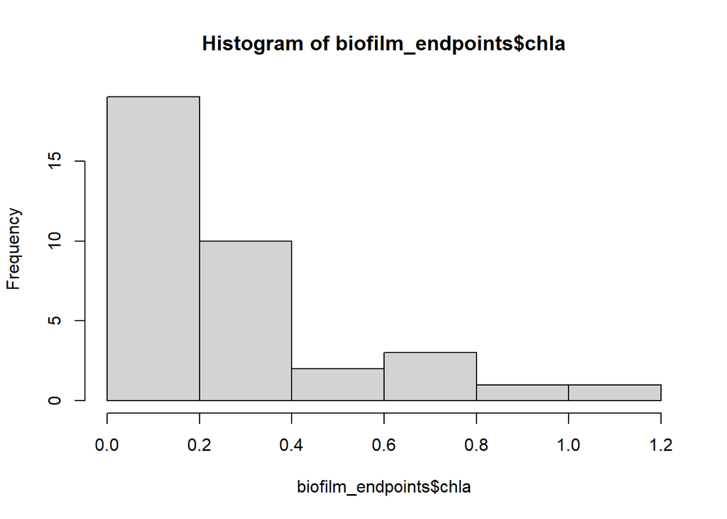

```r
# chl a
hist(biofilm_endpoints $ chla)
```

```r
skewness(biofilm_endpoints $ chla, na.rm = TRUE)
```

```
[1] 1.601648
```

```r
shapiro.test(biofilm_endpoints $ chla)
```

```
    Shapiro-Wilk normality test

data:  biofilm_endpoints$chla
W = 0.78095, p-value = 6.966e-06
```

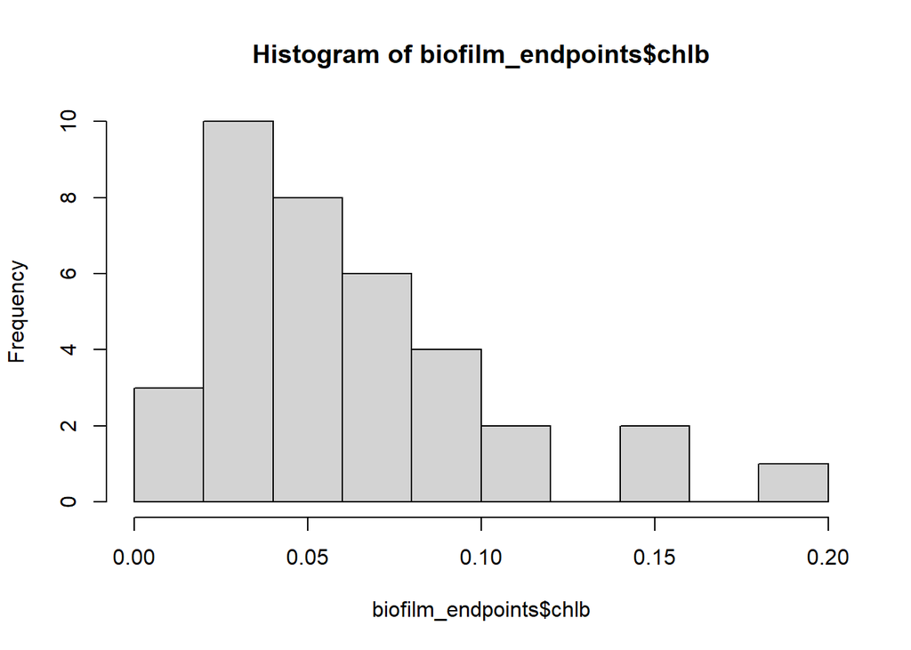

```r
# chl b
hist(biofilm_endpoints $ chlb)
```

```r
skewness(biofilm_endpoints $ chlb, na.rm = TRUE)
```

```
[1] 1.452618
```

```r
shapiro.test(biofilm_endpoints $ chlb)
```

```
    Shapiro-Wilk normality test

data:  biofilm_endpoints$chlb
W = 0.87043, p-value = 0.0005833
```

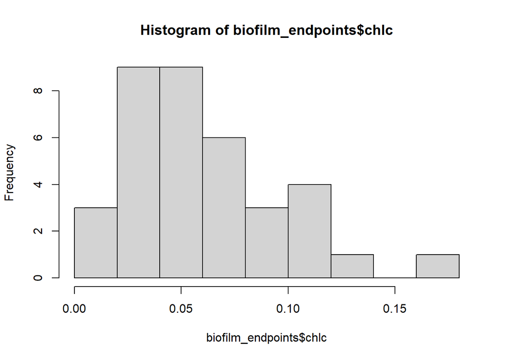

```r
# chl c
hist(biofilm_endpoints $ chlc)
```

```r
skewness(biofilm_endpoints $ chlc, na.rm = TRUE)
```

```
[1] 1.253578
```

```r
shapiro.test(biofilm_endpoints $ chlc)
```

```
    Shapiro-Wilk normality test

data:  biofilm_endpoints$chlc
W = 0.89434, p-value = 0.002398
```

All not normal distributed, right skewed but skewness max. 1.6 therefore no data transformation for model

### 3.1.2 Model chla

Linear model with xenobiotic treatment as explanatory variable.

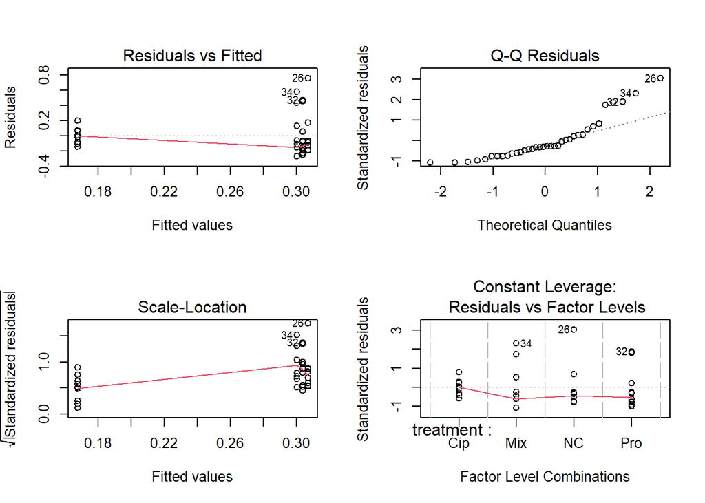

```r
# treatment as factor
biofilm_endpoints $ treatment <- factor(biofilm_endpoints $ treatment)

model_chla <- lm(chla ~ treatment, data = biofilm_endpoints)
par(mfrow = c(2, 2))
plot(model_chla)
```

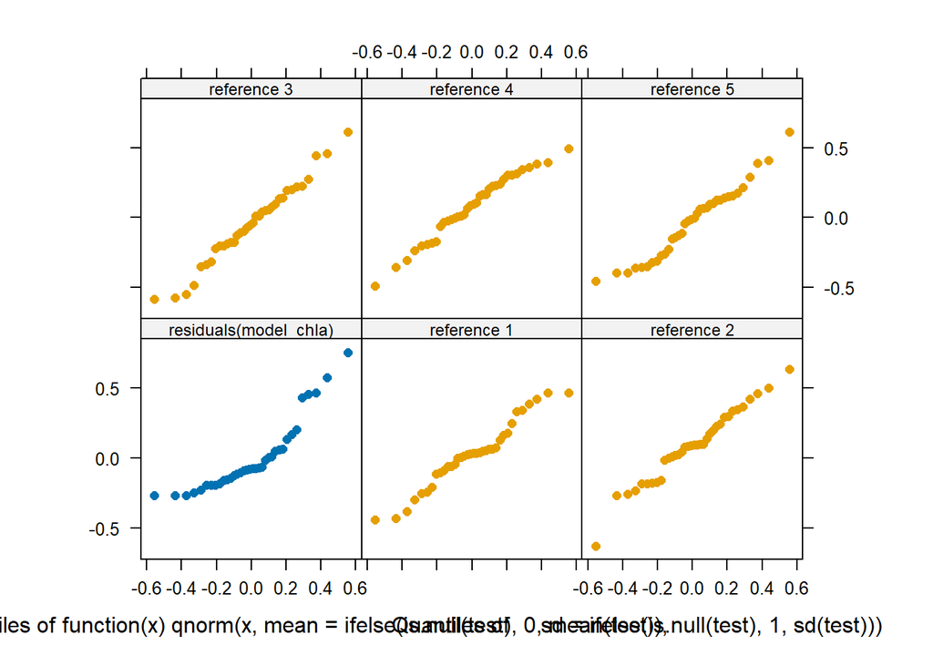

```r
qreference(residuals(model_chla)) # not normal distributed
```

```r
pairwise.wilcox.test(biofilm_endpoints$chla,
                     biofilm_endpoints$treatment,
                     p.adjust.method = "holm")
```

```
    Pairwise comparisons using Wilcoxon rank sum exact test

data:  biofilm_endpoints$chla and biofilm_endpoints$treatment

    Cip Mix NC
Mix 1   -   -
NC  1   1   -
Pro 1   1   1

P value adjustment method: holm
```

```r
# add presence / absence
# interaction effect model with presence / absence of single xenobiotics
biofilm_endpoints$Cip <- ifelse(biofilm_endpoints$treatment %in% c("Cip", "Mix"),
                                1, 0)

biofilm_endpoints$Cip <- factor(biofilm_endpoints$Cip, levels = c(0, 1))

biofilm_endpoints$Pro <- ifelse(biofilm_endpoints$treatment %in% c("Pro", "Mix"),
                                1, 0)

biofilm_endpoints$Pro <- factor(biofilm_endpoints$Pro, levels = c(0, 1))

# sanity check
table(biofilm_endpoints$treatment,
      biofilm_endpoints$Cip,
      biofilm_endpoints$Pro)
```

```
, ,  = 0


      0 1
  Cip 0 9
  Mix 0 0
  NC  9 0
  Pro 0 0

, ,  = 1


      0 1
  Cip 0 0
  Mix 0 9
  NC  0 0
  Pro 9 0
```

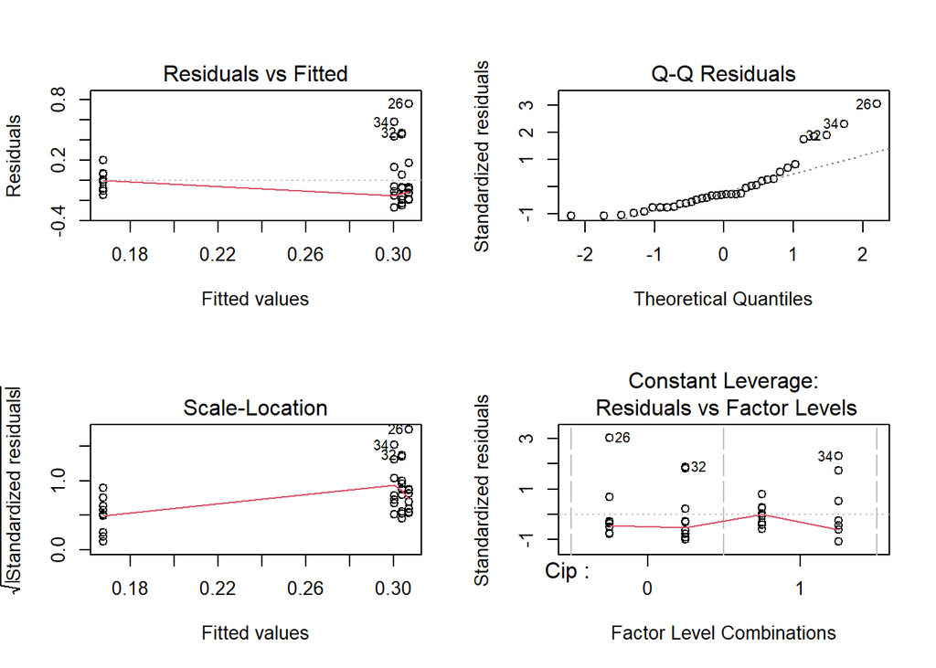

```r
chla_mixture <- lm(chla ~ Cip * Pro, data = biofilm_endpoints)
par(mfrow = c(2, 2))
plot(chla_mixture) # not normally distributed
```

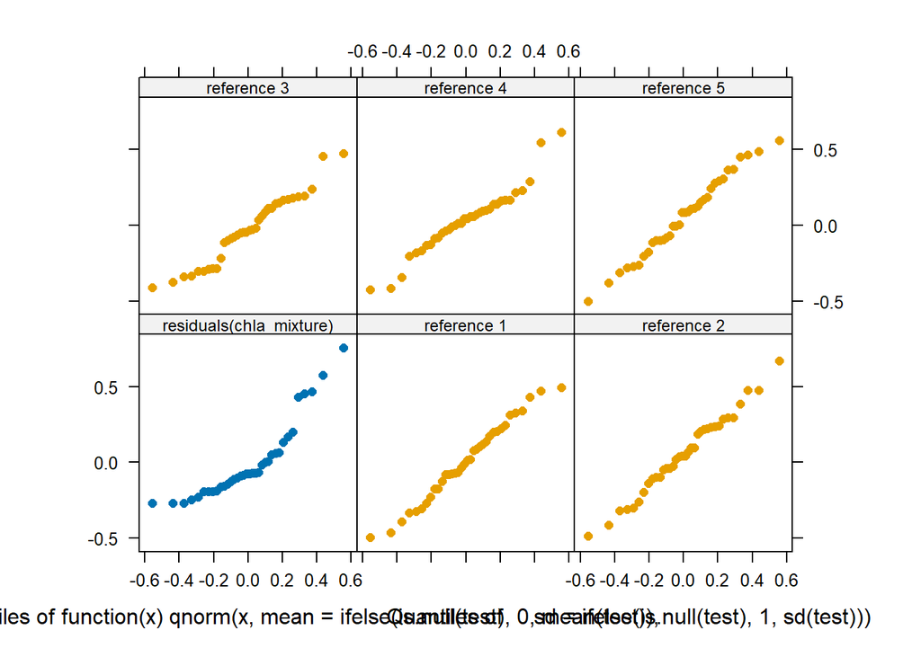

```r
qreference(residuals(chla_mixture))
```

```r
kruskal_chla_interaction <- biofilm_endpoints %>%
  dplyr::mutate(treatment = interaction(Cip, Pro, sep = "_")) %>%
  kruskal.test(chla ~ treatment, data = .)

kruskal_chla_interaction
```

```
    Kruskal-Wallis rank sum test

data:  chla by treatment
Kruskal-Wallis chi-squared = 1.3063, df = 3, p-value = 0.7276
```

```r
# no significant interaction
```

No significant differences between chemical treatments in chlorophyll a content.

### 3.1.3 Model chlb

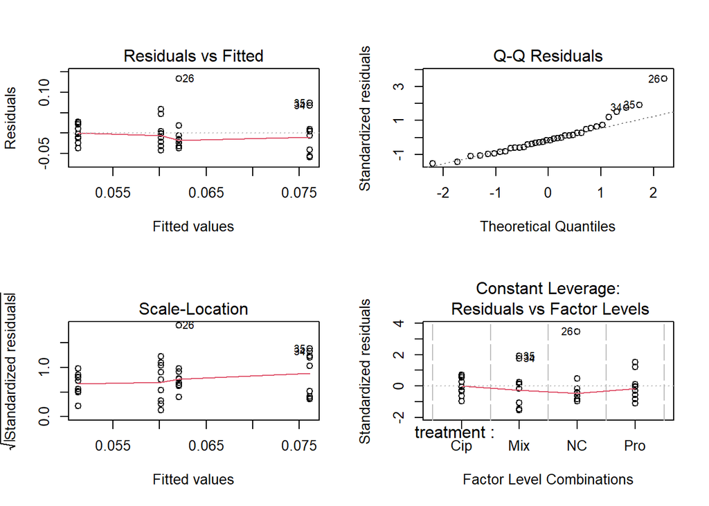

```r
model_chlb <- lm(chlb ~ treatment, data = biofilm_endpoints)
par(mfrow = c(2, 2))
plot(model_chlb)
```

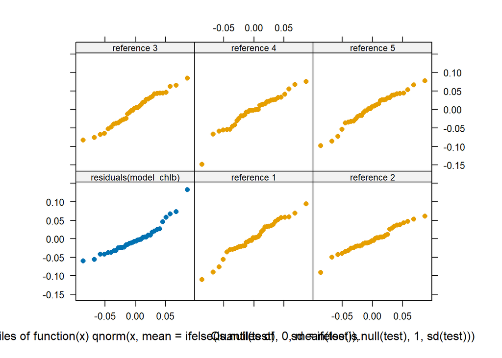

```r
qreference(residuals(model_chlb)) # normality acceptable
```

```r
drop1(model_chlb, test = 'F')
```

```
Single term deletions

Model:
chlb ~ treatment
          Df Sum of Sq      RSS     AIC F value Pr(>F)
<none>                 0.053639 -226.32
treatment  3 0.0028604 0.056500 -230.45  0.5688 0.6396
```

```r
chlb_inter <- lsmeans(model_chlb, ~ treatment)
chlb_inter_dunn1 <- contrast(chlb_inter, 'pairwise')
(chlb_inter_dunn_sum1 <- summary(chlb_inter_dunn1, infer = TRUE, adjust = 'mvt'))
```

```
 contrast  estimate     SE df lower.CL upper.CL t.ratio p.value
 Cip - Mix -0.02487 0.0193 32  -0.0771   0.0274  -1.289  0.5767
 Cip - NC  -0.01080 0.0193 32  -0.0631   0.0415  -0.560  0.9432
 Cip - Pro -0.00888 0.0193 32  -0.0612   0.0434  -0.460  0.9672
 Mix - NC   0.01407 0.0193 32  -0.0382   0.0663   0.729  0.8847
 Mix - Pro  0.01599 0.0193 32  -0.0363   0.0683   0.829  0.8405
 NC - Pro   0.00192 0.0193 32  -0.0504   0.0542   0.100  0.9996

Confidence level used: 0.95
Conf-level adjustment: mvt method for 6 estimates
P value adjustment: mvt method for 6 tests
```

No significant differences between chemical treatments in chlorophyll b content. Still assess potential interaction:

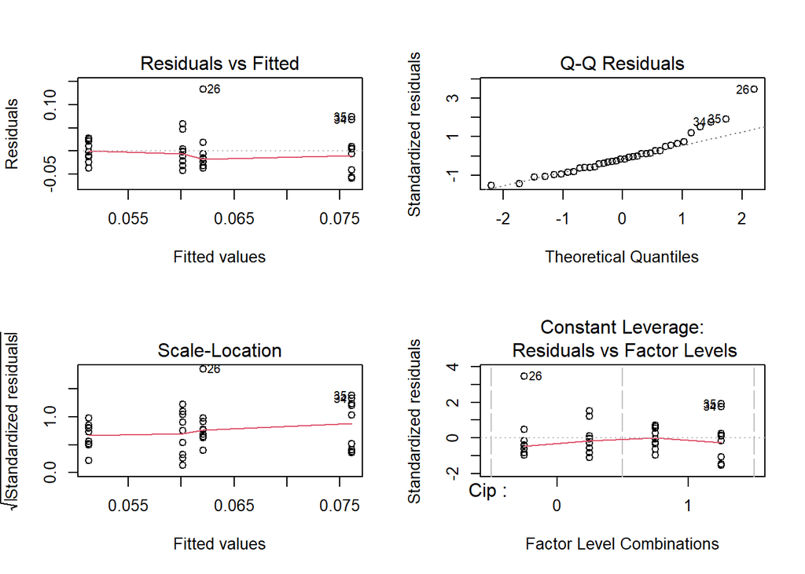

```r
chlb_mixture <- lm(chlb ~ Cip * Pro, data = biofilm_endpoints)
par(mfrow = c(2, 2))
plot(chlb_mixture) # normality acceptable
```

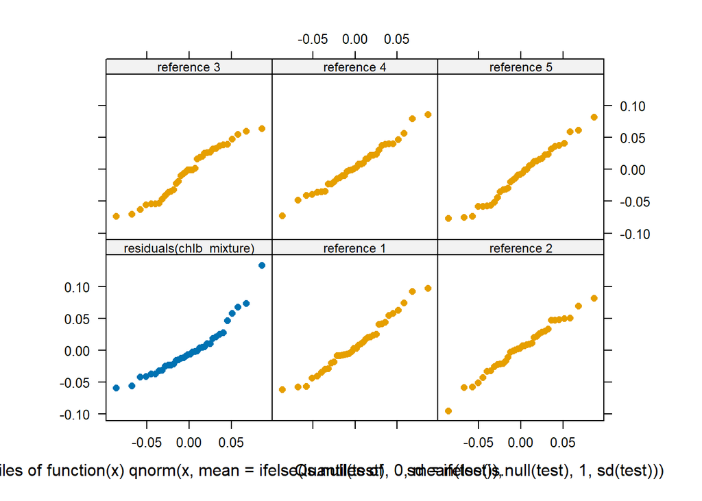

```r
qreference(residuals(chlb_mixture))
```

```r
drop1(chlb_mixture, test = 'F')
```

```
Single term deletions

Model:
chlb ~ Cip * Pro
        Df Sum of Sq      RSS     AIC F value Pr(>F)
<none>               0.053639 -226.32
Cip:Pro  1 0.0016149 0.055254 -227.26  0.9634 0.3337
```

```r
# no significant interaction
```

### 3.1.4 Model chlc

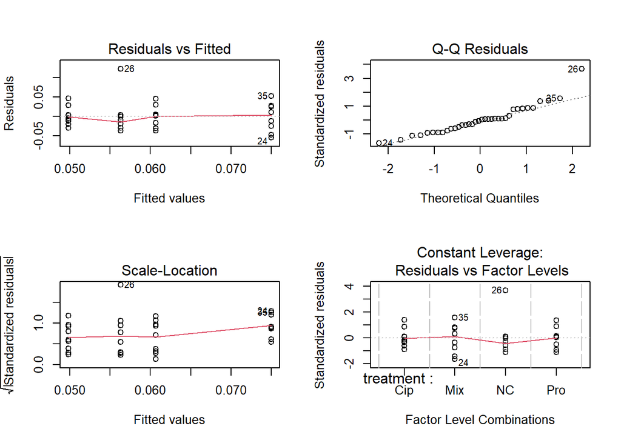

```r
model_chlc <- lm(chlc ~ treatment, data = biofilm_endpoints)
par(mfrow = c(2, 2))
plot(model_chlc) # normality acceptable
```

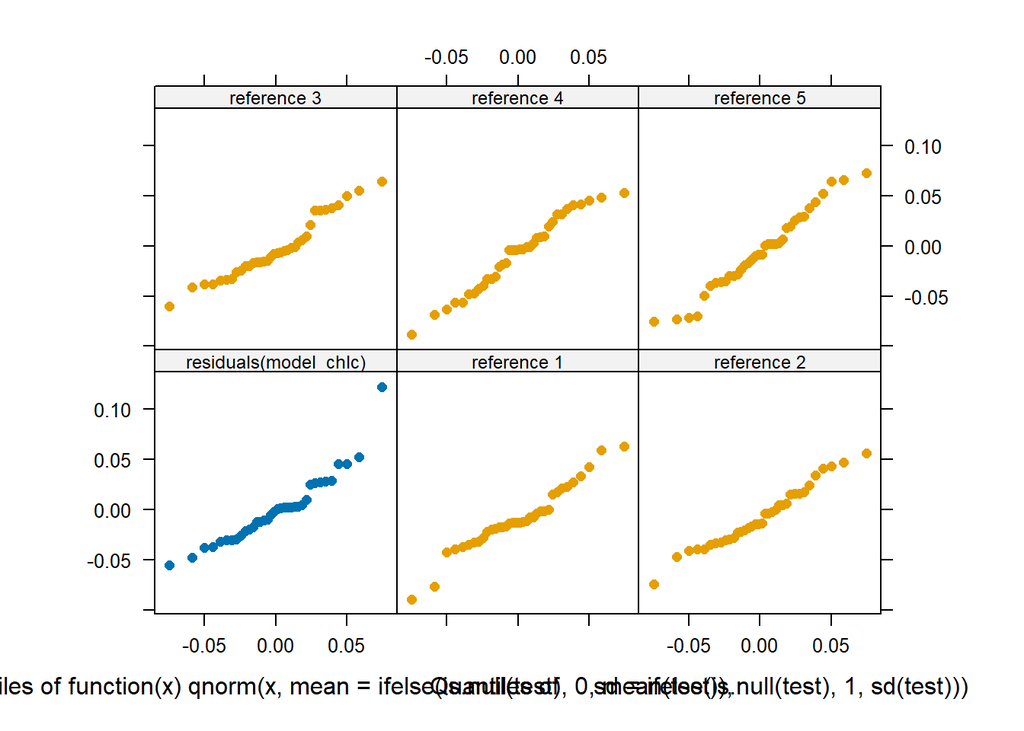

```r
qreference(residuals(model_chlc))
```

```r
drop1(model_chlc, test = 'F')
```

```
Single term deletions

Model:
chlc ~ treatment
          Df Sum of Sq      RSS     AIC F value Pr(>F)
<none>                 0.039915 -236.96
treatment  3 0.0030658 0.042981 -240.30  0.8193 0.4928
```

No significant differences between chemical treatments in chlorophyll c content. Still check for interactions of Cip * Pro:

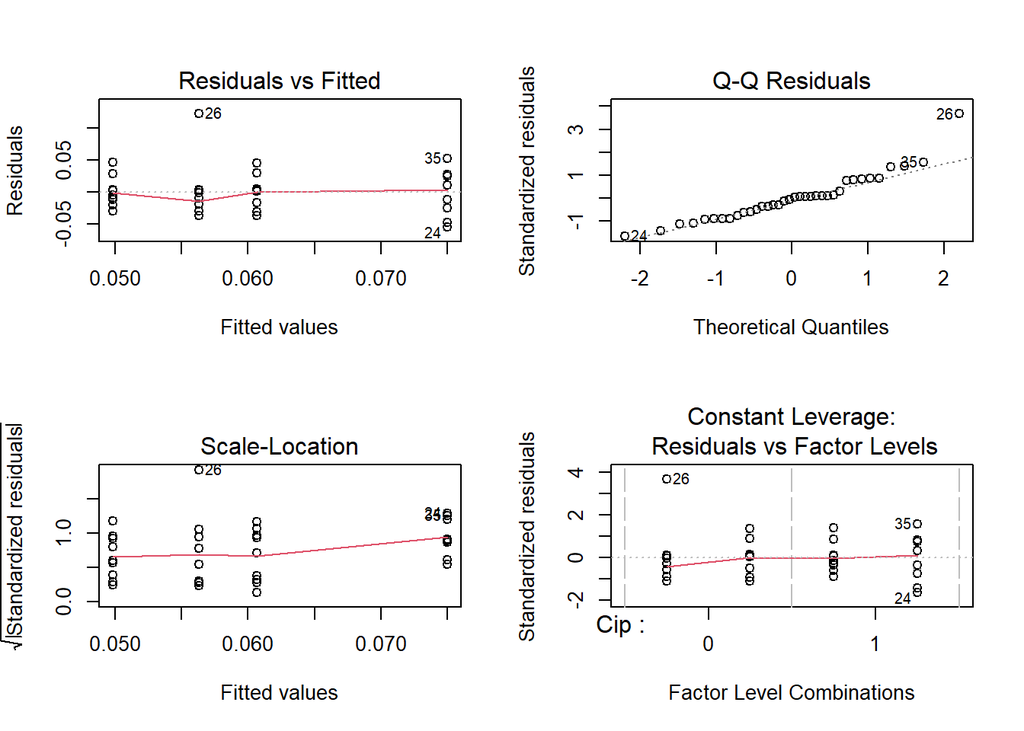

```r
chlc_mixture <- lm(chlc ~ Cip * Pro, data = biofilm_endpoints)
par(mfrow = c(2, 2))
plot(chlc_mixture) # normality acceptable
```

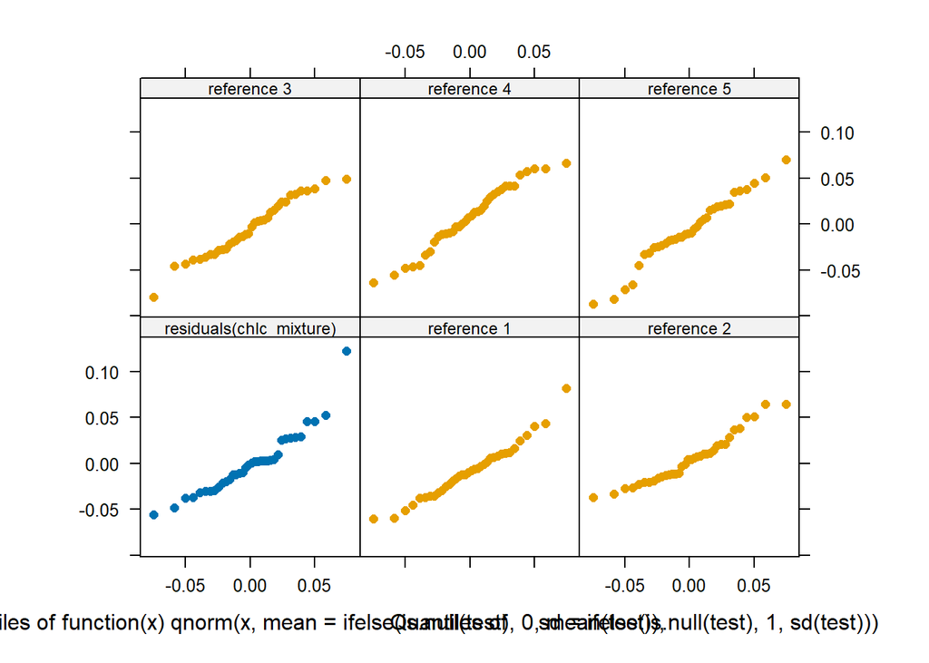

```r
qreference(residuals(chlc_mixture))
```

```r
drop1(chlc_mixture, test = 'F')
```

```
Single term deletions

Model:
chlc ~ Cip * Pro
        Df Sum of Sq      RSS     AIC F value Pr(>F)
<none>               0.039915 -236.96
Cip:Pro  1 0.0009716 0.040887 -238.10  0.7789 0.3841
```

```r
# no significant interaction
```

### 3.1.5 Graphs chlorophyll a, b + c

```r
# chl a
chla_plot <-
  ggplot(data = biofilm_endpoints,
         mapping = aes(x = factor(
           treatment, levels = c("NC", "Pro", "Cip", "Mix")
         ), y = chla)) +
  # Mean
  stat_summary(
    fun = mean,
    geom = "point",
    aes(fill = treatment),
    shape = 21,
    size = 5,
    color = "grey20",
    stroke = 0.5
  ) +

  # 95% CI
  # Black outline (thicker, underneath)
  stat_summary(
    fun.data = mean_cl_normal,
    geom = "errorbar",
    aes(group = treatment),
    width = 0.2,
    linewidth = 1,
    color = "grey30"
  ) +

  # Colored CI on top
  stat_summary(
    fun.data = mean_cl_normal,
    geom = "errorbar",
    aes(color = treatment),
    width = 0.2,
    linewidth = 0.8
  ) +

  # Jittered
  geom_point(
    aes(color = treatment),
    position = position_jitter(width = 0.25, height = 0),
    alpha = 0.8,
    size = 2
  ) +

  # Color scales
  scale_fill_manual(values = c(
    "NC" = "#009E73",
    "Pro" = "#E69F00",
    "Cip" = "#56B4E9",
    "Mix" = "#999999"
  )) +
  scale_color_manual(values = c(
    "NC" = "#009E73",
    "Pro" = "#E69F00",
    "Cip" = "#56B4E9",
    "Mix" = "#999999"
  )) +
  guides(fill = "none") +

  # Theme and labels
  labs(x = NULL,
       y = expression(bold("Chl a (µg/cm" ^ "2" * ")")),
       color = "") +
  scale_x_discrete(labels = NULL) +
  theme_minimal(base_size = 11) +
  theme(
    legend.position = "none",
    panel.background = element_rect(fill = "grey100"),
    axis.title.y = element_text(
      size = 13,
      face = "bold",
      colour = "grey30"
  ),
    axis.text.x = element_text(size = 12),
    axis.text.y = element_text(size = 12),
    panel.border = element_rect(fill = NA, colour = "grey30"),
    panel.grid.major = element_line(colour = "grey85", size = 0.4),
    panel.grid.minor = element_line(colour = "grey95", size = 0.2)
  )
# Chlorophyll b
chlb_plot <-
  ggplot(data = biofilm_endpoints,
         mapping = aes(x = factor(
           treatment, levels = c("NC", "Pro", "Cip", "Mix")
         ), y = chlb)) +
  # Mean
  stat_summary(
    fun = mean,
    geom = "point",
    aes(fill = treatment),
    shape = 21,
    size = 5,
    color = "grey20",
    stroke = 0.5
  ) +

  # 95% CI
  # Black outline (thicker, underneath)
  stat_summary(
    fun.data = mean_cl_normal,
    geom = "errorbar",
    aes(group = treatment),
    width = 0.2,
    linewidth = 1,
    color = "grey30"
  ) +

  # Colored CI on top
  stat_summary(
    fun.data = mean_cl_normal,
    geom = "errorbar",
    aes(color = treatment),
    width = 0.2,
    linewidth = 0.8
  ) +

  # Jittered
  geom_point(
    aes(color = treatment),
    position = position_jitter(width = 0.25, height = 0),
    alpha = 0.8,
    size = 2
  ) +

  # Color scales
  scale_fill_manual(values = c(
    "NC" = "#009E73",
    "Pro" = "#E69F00",
    "Cip" = "#56B4E9",
    "Mix" = "#999999"
  )) +
  scale_color_manual(values = c(
    "NC" = "#009E73",
    "Pro" = "#E69F00",
    "Cip" = "#56B4E9",
    "Mix" = "#999999"
  )) +
  guides(fill = "none") +

  # Theme and labels
  labs(x = NULL,
       y = expression(bold("Chl b (µg/cm" ^ "2" * ")")),
       color = "") +
  scale_x_discrete(labels = NULL) +
  theme_minimal(base_size = 11) +
  theme(
    legend.position = "none",
    panel.background = element_rect(fill = "grey100"),
    axis.title = element_text(
      size = 13,
      face = "bold",
      colour = "grey30"
    ),
    axis.text.x = element_text(size = 12),
    axis.text.y = element_text(size = 12),
    panel.border = element_rect(fill = NA, colour = "grey30"),
    panel.grid.major = element_line(colour = "grey85", size = 0.4),
    panel.grid.minor = element_line(colour = "grey95", size = 0.2)
  )

# Chlorophyll c
chlc_plot <-
  ggplot(data = biofilm_endpoints,
         mapping = aes(x = factor(
           treatment, levels = c("NC", "Pro", "Cip", "Mix")
         ), y = chlc)) +
  # Mean
  stat_summary(
    fun = mean,
    geom = "point",
    aes(fill = treatment),
    shape = 21,
    size = 5,
    color = "grey20",
    stroke = 0.5
  ) +

  # 95% CI
  # Black outline (thicker, underneath)
  stat_summary(
    fun.data = mean_cl_normal,
    geom = "errorbar",
    aes(group = treatment),
    width = 0.2,
    linewidth = 1,
    color = "grey30"
  ) +

  # Colored CI on top
  stat_summary(
    fun.data = mean_cl_normal,
    geom = "errorbar",
    aes(color = treatment),
    width = 0.2,
    linewidth = 0.8
  ) +

  # Jittered
  geom_point(
    aes(color = treatment),
    position = position_jitter(width = 0.25, height = 0),
    alpha = 0.8,
    size = 2
  ) +

  # Color scales
  scale_fill_manual(values = c(
    "NC" = "#009E73",
    "Pro" = "#E69F00",
    "Cip" = "#56B4E9",
    "Mix" = "#999999"
  )) +
  scale_color_manual(values = c(
    "NC" = "#009E73",
    "Pro" = "#E69F00",
    "Cip" = "#56B4E9",
    "Mix" = "#999999"
  )) +
  guides(fill = "none") +

  # Theme and labels
  labs(x = "Treatment",
       y = expression(bold("Chl c (µg/cm" ^ "2" * ")")),
       color = "") +
  scale_x_discrete(labels = c("Control", "Propyzamide", "Ciprofloxacin", "Mixture")) +
  theme_minimal(base_size = 11) +
  theme(
    legend.position = "none",
    panel.background = element_rect(fill = "grey100"),
    axis.title = element_text(
      size = 13,
      face = "bold",
      colour = "grey30"
    ),
    axis.text.x = element_text(size = 11),
    axis.text.y = element_text(size = 12),
    panel.border = element_rect(fill = NA, colour = "grey30"),
    panel.grid.major = element_line(colour = "grey85", size = 0.4),
    panel.grid.minor = element_line(colour = "grey95", size = 0.2)
  )

# combine and save with AFDW plot later
```

## 3.2 AFDW

Calculate mean, se and 95% CI AFDW of each treatment.

```r
mean_afdw <- biofilm_endpoints %>%
  group_by(treatment) %>%
  dplyr::summarize(
    mean_afdw = mean(afdw, na.rm = TRUE),
    n = sum(!is.na(afdw)),
    se = sd(afdw, na.rm = TRUE) / sqrt(n),
    t_crit = qt(0.975, df = n - 1),
    ci_lower = mean_afdw - t_crit * se,
    ci_upper = mean_afdw + t_crit * se,
    .groups = "drop"
  ) %>%
  dplyr::select(treatment, mean_afdw, ci_lower, ci_upper, se)

print(mean_afdw)
```

```
# A tibble: 4 × 5
  treatment mean_afdw ci_lower ci_upper     se
  <fct>         <dbl>    <dbl>    <dbl>  <dbl>
1 Cip           0.125   0.0832    0.167 0.0182
2 Mix           0.142   0.0430    0.240 0.0428
3 NC            0.273   0.104     0.441 0.0730
4 Pro           0.226   0.0749    0.378 0.0657
```

### 3.2.1 Histogram AFDW after colonisation

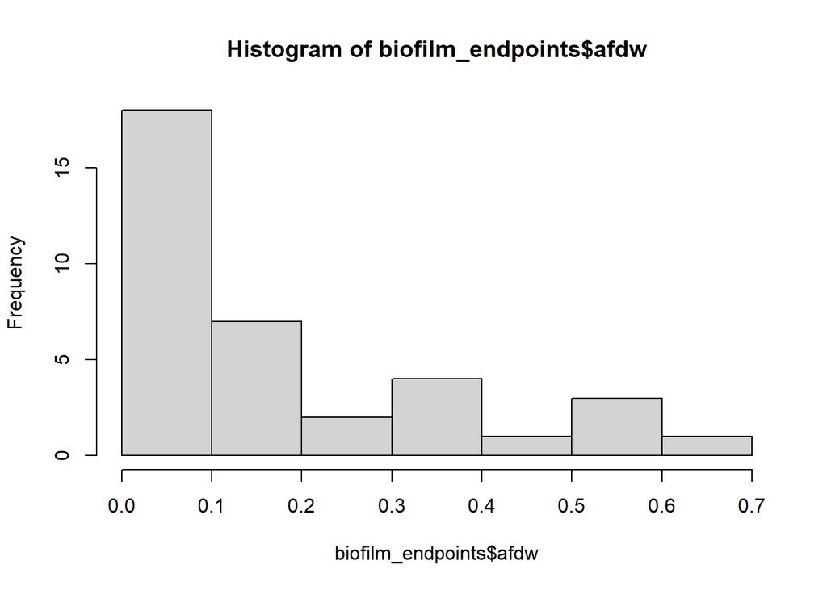

```r
hist(biofilm_endpoints $ afdw)
```

```r
skewness(biofilm_endpoints $ afdw, na.rm = TRUE)
```

```
[1] 1.433642
```

```r
shapiro.test(biofilm_endpoints $ afdw)
```

```
    Shapiro-Wilk normality test

data:  biofilm_endpoints$afdw
W = 0.759, p-value = 2.751e-06
```

Not normal distributed, right skewed but skewness <1.5 therefore no data transformation for model.

### 3.2.2 Model AFDW

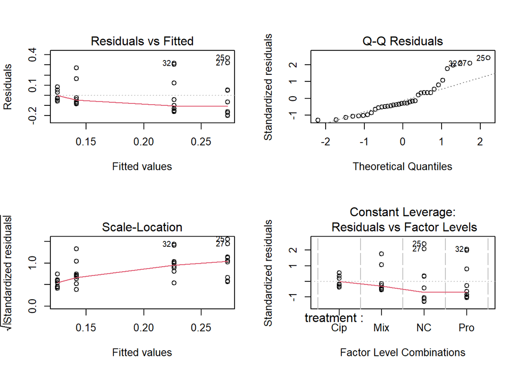

```r
model_afdw <- lm(afdw ~ treatment, data = biofilm_endpoints)
par(mfrow = c(2, 2))
plot(model_afdw) # rather s shape
```

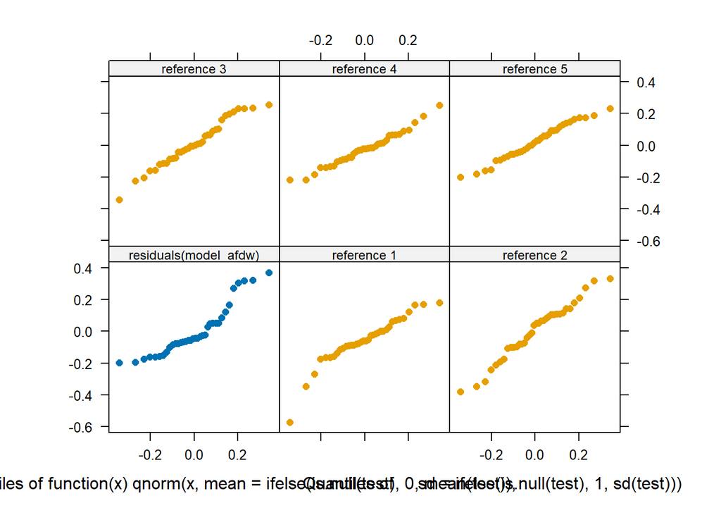

```r
qreference(residuals(model_afdw))
```

```r
pairwise.wilcox.test(biofilm_endpoints$afdw,
                     biofilm_endpoints$treatment,
                     p.adjust.method = "holm")
```

```
    Pairwise comparisons using Wilcoxon rank sum exact test

data:  biofilm_endpoints$afdw and biofilm_endpoints$treatment

    Cip  Mix  NC
Mix 1.00 -    -
NC  0.68 0.51 -
Pro 1.00 1.00 1.00

P value adjustment method: holm
```

No significant differences for treatment variable of total biofilm biomass.

### 3.2.3 Boxplot AFDW

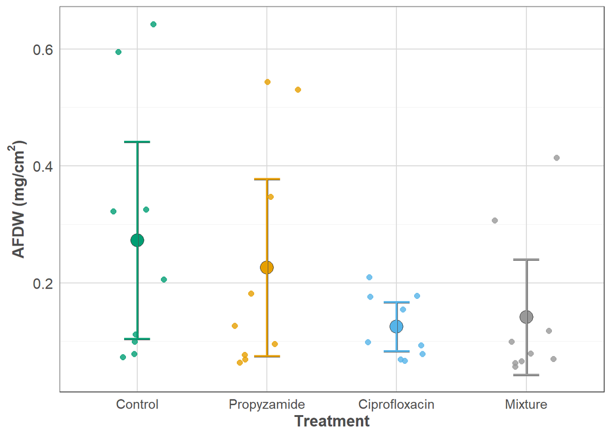

```r
afdw_boxplot <-
  ggplot(data = biofilm_endpoints,
         mapping = aes(x = factor(
           treatment, levels = c("NC", "Pro", "Cip", "Mix")
         ), y = afdw)) +
  # Mean
  stat_summary(
    fun = mean,
    geom = "point",
    aes(fill = treatment),
    shape = 21,
    size = 5,
    color = "grey20",
    stroke = 0.5
  ) +

  # 95% CI
  # Black outline (thicker, underneath)
  stat_summary(
    fun.data = mean_cl_normal,
    geom = "errorbar",
    aes(group = treatment),
    width = 0.2,
    linewidth = 1,
    color = "grey30"
  ) +

  # Colored CI on top
  stat_summary(
    fun.data = mean_cl_normal,
    geom = "errorbar",
    aes(color = treatment),
    width = 0.2,
    linewidth = 0.8
  ) +

  # Jittered
  geom_point(
    aes(color = treatment),
    position = position_jitter(width = 0.25, height = 0),
    alpha = 0.8,
    size = 2
  ) +

  # Color scales
  scale_fill_manual(values = c(
    "NC" = "#009E73",
    "Pro" = "#E69F00",
    "Cip" = "#56B4E9",
    "Mix" = "#999999"
  )) +
  scale_color_manual(values = c(
    "NC" = "#009E73",
    "Pro" = "#E69F00",
    "Cip" = "#56B4E9",
    "Mix" = "#999999"
  )) +
  guides(fill = "none") +

  # Theme and labels
  labs(x = "Treatment",
       y = expression(bold("AFDW (mg/cm"^"2"*")")),
       color = "") +
  scale_x_discrete(labels = c("Control", "Propyzamide", "Ciprofloxacin", "Mixture")) +
  theme_minimal(base_size = 11) +
  theme(
    legend.position = "none",
    panel.background = element_rect(fill = "grey100"),
    axis.title = element_text(
      size = 13,
      face = "bold",
      colour = "grey30"
    ),
    axis.text.x = element_text(size = 11),
    axis.text.y = element_text(size = 12),
    panel.border = element_rect(fill = NA, colour = "grey30"),
    panel.grid.major = element_line(colour = "grey85", size = 0.4),
    panel.grid.minor = element_line(colour = "grey95", size = 0.2)
  )


afdw_boxplot
```

```r
# Now combine with chlorophyll plots
combined_plot <- chla_plot / chlb_plot / chlc_plot / afdw_boxplot +
  plot_layout(ncol = 2)

# save the plot
ggsave(
  "output/biofilm_endpoints.png",
  plot = combined_plot,
  width = 25,
  height = 30,
  units = "cm",
  dpi = 600
)
```

# 4 Fatty acid composition biofilm

Statistics for fatty acid composition of the biofilm in absolute values (µg fatty acid / mg dry weight biofilm).

```r
# insert data
FA_Biofilm_absolute <-
  read.table(file.path("data\\FA_Biofilm_absolute.txt"),
             header = TRUE,
             sep = "\t")

View(FA_Biofilm_absolute)
```

## 4.1 Absolute SAFA, MUFA & PUFA concentrations

1) Total SAFA content

```r
# total SAFA, MUFA, PUFA content; ba = "biofilm absolute"
# total SAFA content
# filter saturated fatty acids in new table
SAFA_ba <- FA_Biofilm_absolute %>%
    filter(fa %in% c("C08:0", "C10:0", "C11:0","C12:0", "C13:0", "C14:0", "C15:0", "C16:0", "C18:0", "C20:0", "C21:0", "C22:0", "C24:0"))

# Sum SAFA per replicate and treatment
total_SAFA_per_replicate <- SAFA_ba %>%
  dplyr::group_by(replicate, treatment) %>%
  dplyr::summarize(sum_SAFA = sum(fa_conc), .groups = "drop")
print(total_SAFA_per_replicate)
```

```
# A tibble: 12 × 3
   replicate treatment sum_SAFA
   <chr>     <chr>        <dbl>
 1 B_1       NC            84.3
 2 B_10      Cip           67.8
 3 B_11      Pro           68.0
 4 B_12      Mix           64.4
 5 B_2       Cip           72.1
 6 B_3       Pro           36.5
 7 B_4       Mix           90.4
 8 B_5       NC            83.0
 9 B_6       Cip           81.2
10 B_7       Pro           71.3
11 B_8       Mix           61.1
12 B_9       NC           122.
```

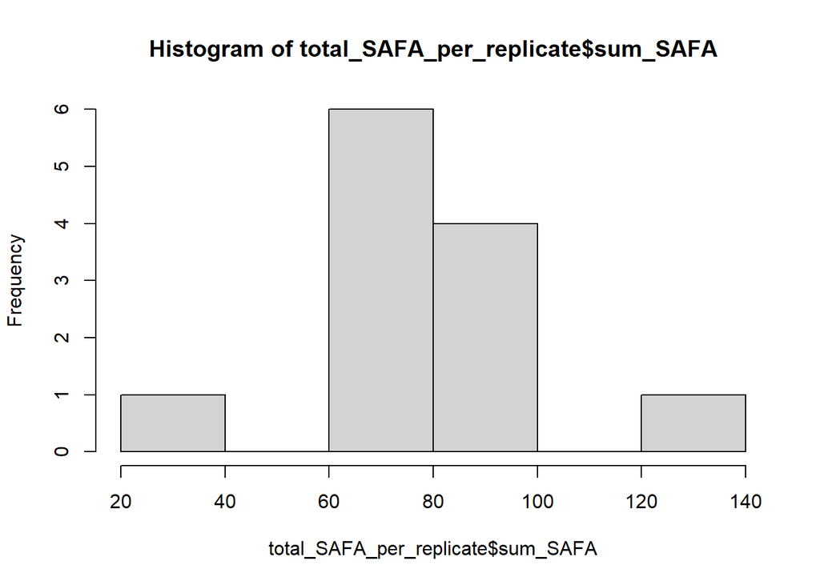

```r
# Statistical differences
hist(total_SAFA_per_replicate $ sum_SAFA) # normal distributed
```

```r
shapiro.test(total_SAFA_per_replicate $ sum_SAFA) # normal distributed
```

```
    Shapiro-Wilk normality test

data:  total_SAFA_per_replicate$sum_SAFA
W = 0.92447, p-value = 0.3252
```

```r
leveneTest(sum_SAFA ~ treatment, data = total_SAFA_per_replicate) # homogenous
```

```
Levene's Test for Homogeneity of Variance (center = median)
      Df F value Pr(>F)
group  3  0.1736 0.9112
       8
```

```r
anova_SAFA <- aov(sum_SAFA ~ treatment, data = total_SAFA_per_replicate)
summary(anova_SAFA)
```

```
            Df Sum Sq Mean Sq F value Pr(>F)
treatment    3   2241   746.9   2.543   0.13
Residuals    8   2350   293.8
```

```r
TukeyHSD(anova_SAFA)
```

```
  Tukey multiple comparisons of means
    95% family-wise confidence level

Fit: aov(formula = sum_SAFA ~ treatment, data = total_SAFA_per_replicate)

$treatment
              diff       lwr       upr     p adj
Mix-Cip  -1.723539 -46.53926 43.092185 0.9992740
NC-Cip   22.927247 -21.88848 67.742971 0.4115762
Pro-Cip -15.088489 -59.90421 29.727236 0.7114942
NC-Mix   24.650786 -20.16494 69.466510 0.3559698
Pro-Mix -13.364950 -58.18067 31.450774 0.7774737
Pro-NC  -38.015736 -82.83146  6.799988 0.0992573
```

```r
# Calculate mean, se and 95% CI per treatment
mean_SAFA_ba <- total_SAFA_per_replicate %>%
  dplyr::group_by(treatment) %>%
  dplyr::summarize(
    mean_SAFA = mean(sum_SAFA, na.rm = TRUE),
    n = sum(!is.na(sum_SAFA)),
    se = sd(sum_SAFA, na.rm = TRUE) / sqrt(n),
    t_crit = qt(0.975, df = n - 1),
    ci_lower = mean_SAFA - t_crit * se,
    ci_upper = mean_SAFA + t_crit * se,
    .groups = "drop"
  ) %>%
  dplyr::select(treatment, mean_SAFA, ci_lower, ci_upper, se)

# Extract mean of control group for percental difference
control_mean_SAFA_ba <- mean_SAFA_ba %>%
  filter(treatment == "NC") %>%
  pull(mean_SAFA)

# Calculate percental difference from control
mean_SAFA_ba <- mean_SAFA_ba %>%
  mutate(percent_diff_from_NC = 100 * (mean_SAFA - control_mean_SAFA_ba) / control_mean_SAFA_ba)

print(mean_SAFA_ba)
```

```
# A tibble: 4 × 6
  treatment mean_SAFA ci_lower ci_upper    se percent_diff_from_NC
  <chr>         <dbl>    <dbl>    <dbl> <dbl>                <dbl>
1 Cip            73.7     56.7     90.6  3.94                -23.7
2 Mix            72.0     32.1    112.   9.28                -25.5
3 NC             96.6     40.9    152.  12.9                   0
4 Pro            58.6     10.9    106.  11.1                 -39.3
```

2) Total MUFA content

```r
# filter mono-unsaturated fatty acids in new table
MUFA_ba <- FA_Biofilm_absolute %>%
  filter(fa %in% c("C14:1", "C15:1","C16:1", "C17:1", "C18:1", "C20:1","C22:1", "C24:1"))

# Sum MUFA per replicate and treatment
total_MUFA_per_replicate <- MUFA_ba %>%
  dplyr::group_by(replicate, treatment) %>%
  dplyr::summarize(sum_MUFA = sum(fa_conc), .groups = "drop")
print(total_MUFA_per_replicate)
```

```
# A tibble: 12 × 3
   replicate treatment sum_MUFA
   <chr>     <chr>        <dbl>
 1 B_1       NC           102.
 2 B_10      Cip           68.7
 3 B_11      Pro           55.7
 4 B_12      Mix           33.7
 5 B_2       Cip           81.3
 6 B_3       Pro           67.5
 7 B_4       Mix           49.6
 8 B_5       NC            59.0
 9 B_6       Cip           96.3
10 B_7       Pro           72.4
11 B_8       Mix           58.6
12 B_9       NC            97.3
```

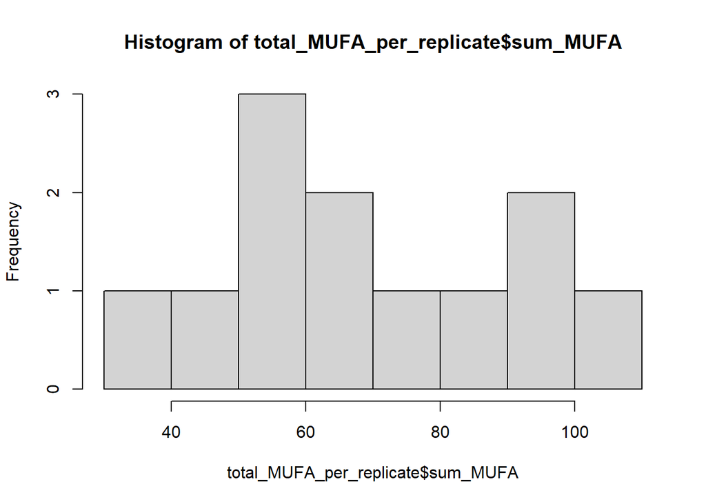

```r
# Statistical differences
hist(total_MUFA_per_replicate $ sum_MUFA) # normal distributed
```

```r
shapiro.test(total_MUFA_per_replicate $ sum_MUFA) # normal distributed
```

```
    Shapiro-Wilk normality test

data:  total_MUFA_per_replicate$sum_MUFA
W = 0.95602, p-value = 0.7259
```

```r
leveneTest(sum_MUFA ~ treatment, data = total_MUFA_per_replicate) # homogenous
```

```
Levene's Test for Homogeneity of Variance (center = median)
      Df F value Pr(>F)
group  3  0.2765 0.8409
       8
```

```r
anova_MUFA <- aov(sum_MUFA ~ treatment, data = total_MUFA_per_replicate)
summary(anova_MUFA)
```

```
            Df Sum Sq Mean Sq F value Pr(>F)
treatment    3   2841     947   3.849 0.0566 .
Residuals    8   1968     246
---
Signif. codes:  0 '***' 0.001 '**' 0.01 '*' 0.05 '.' 0.1 ' ' 1
```

```r
TukeyHSD(anova_MUFA)
```

```
  Tukey multiple comparisons of means
    95% family-wise confidence level

Fit: aov(formula = sum_MUFA ~ treatment, data = total_MUFA_per_replicate)

$treatment
              diff        lwr       upr     p adj
Mix-Cip -34.773175 -75.784607  6.238258 0.0994267
NC-Cip    4.132362 -36.879070 45.143794 0.9875215
Pro-Cip -16.913534 -57.924966 24.097899 0.5762699
NC-Mix   38.905537  -2.105896 79.916969 0.0630459
Pro-Mix  17.859641 -23.151792 58.871073 0.5358323
Pro-NC  -21.045896 -62.057328 19.965537 0.4091840
```

```r
# Calculate mean, se and 95% CI per treatment
mean_MUFA_ba <- total_MUFA_per_replicate %>%
  dplyr::group_by(treatment) %>%
  dplyr::summarize(
    mean_MUFA = mean(sum_MUFA, na.rm = TRUE),
    n = sum(!is.na(sum_MUFA)),
    se = sd(sum_MUFA, na.rm = TRUE) / sqrt(n),
    t_crit = qt(0.975, df = n - 1),
    ci_lower = mean_MUFA - t_crit * se,
    ci_upper = mean_MUFA + t_crit * se,
    .groups = "drop"
  ) %>%
  dplyr::select(treatment, mean_MUFA, ci_lower, ci_upper, se)

# Extract mean of control group for percental difference
control_mean_MUFA_ba <- mean_MUFA_ba %>%
  filter(treatment == "NC") %>%
  pull(mean_MUFA)

# Calculate percental difference from control
mean_MUFA_ba <- mean_MUFA_ba %>%
  mutate(percent_diff_from_NC = 100 * (mean_MUFA - control_mean_MUFA_ba) / control_mean_MUFA_ba)

print(mean_MUFA_ba)
```

```
# A tibble: 4 × 6
  treatment mean_MUFA ci_lower ci_upper    se percent_diff_from_NC
  <chr>         <dbl>    <dbl>    <dbl> <dbl>                <dbl>
1 Cip            82.1     47.7    116.   7.99                -4.79
2 Mix            47.3     16.1     78.6  7.26               -45.1
3 NC             86.2     27.4    145.  13.7                  0
4 Pro            65.2     43.9     86.5  4.95               -24.4
```

3) Total PUFA content

```r
# filter poly-unsaturated fatty acids in new table
PUFA_ba <- FA_Biofilm_absolute %>%
  filter(fa %in% c("C18:2(n-6c)", "C18:2(n-6t)", "C18:3(n-3)", "C18:3(n-6)", "C18:4(n-3)", "C20:2(n-6)", "C20:3(n-3)", "C20:3(n-6)", "C20:4(n-6)", "C20:5(n-3)", "C22:2", "C22:5(n-3)", "C22:6(n-3)"))

# Sum PUFA per replicate and treatment
total_PUFA_per_replicate <- PUFA_ba %>%
  dplyr::group_by(replicate, treatment) %>%
  dplyr::summarize(sum_PUFA = sum(fa_conc), .groups = "drop")
print(total_PUFA_per_replicate)
```

```
# A tibble: 12 × 3
   replicate treatment sum_PUFA
   <chr>     <chr>        <dbl>
 1 B_1       NC            73.2
 2 B_10      Cip          122.
 3 B_11      Pro           68.3
 4 B_12      Mix          117.
 5 B_2       Cip           74.1
 6 B_3       Pro           85.0
 7 B_4       Mix           72.8
 8 B_5       NC           117.
 9 B_6       Cip           86.5
10 B_7       Pro           66.6
11 B_8       Mix           46.2
12 B_9       NC           132.
```

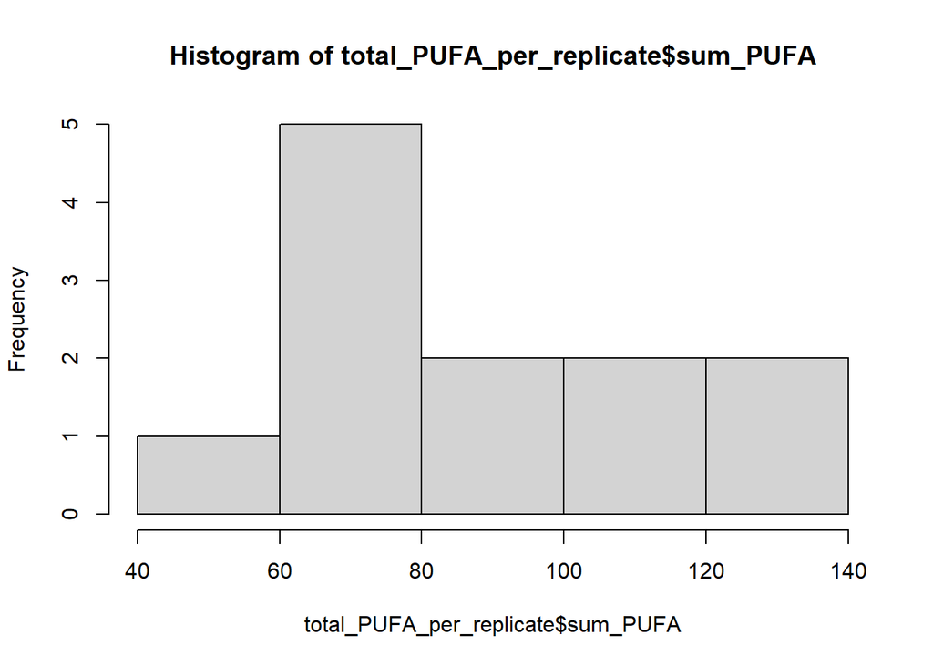

```r
# Statistical differences
hist(total_PUFA_per_replicate $ sum_PUFA) # normal distributed
```

```r
shapiro.test(total_PUFA_per_replicate $ sum_PUFA) # normal distributed
```

```
    Shapiro-Wilk normality test

data:  total_PUFA_per_replicate$sum_PUFA
W = 0.9096, p-value = 0.2108
```

```r
leveneTest(sum_PUFA ~ treatment, data = total_PUFA_per_replicate) # homogenous
```

```
Levene's Test for Homogeneity of Variance (center = median)
      Df F value Pr(>F)
group  3  0.4873 0.7005
       8
```

```r
anova_PUFA <- aov(sum_PUFA ~ treatment, data = total_PUFA_per_replicate)
summary(anova_PUFA)
```

```
            Df Sum Sq Mean Sq F value Pr(>F)
treatment    3   2134   711.3   0.968  0.454
Residuals    8   5878   734.8
```

```r
TukeyHSD(anova_PUFA)
```

```
  Tukey multiple comparisons of means
    95% family-wise confidence level

Fit: aov(formula = sum_PUFA ~ treatment, data = total_PUFA_per_replicate)

$treatment
              diff        lwr      upr     p adj
Mix-Cip -15.305215  -86.18122 55.57078 0.8975126
NC-Cip   13.234611  -57.64139 84.11061 0.9298606
Pro-Cip -20.802129  -91.67813 50.07387 0.7852597
NC-Mix   28.539826  -42.33617 99.41583 0.5935723
Pro-Mix  -5.496914  -76.37291 65.37909 0.9941861
Pro-NC  -34.036740 -104.91274 36.83926 0.4607233
```

```r
# Calculate mean, se and 95% CI per treatment
mean_PUFA_ba <- total_PUFA_per_replicate %>%
  dplyr::group_by(treatment) %>%
  dplyr::summarize(
    mean_PUFA = mean(sum_PUFA, na.rm = TRUE),
    n = sum(!is.na(sum_PUFA)),
    se = sd(sum_PUFA, na.rm = TRUE) / sqrt(n),
    t_crit = qt(0.975, df = n - 1),
    ci_lower = mean_PUFA - t_crit * se,
    ci_upper = mean_PUFA + t_crit * se,
    .groups = "drop"
  ) %>%
  dplyr::select(treatment, mean_PUFA, ci_lower, ci_upper, se)

# Extract mean of control group for percental difference
control_mean_PUFA_ba <- mean_PUFA_ba %>%
  filter(treatment == "NC") %>%
  pull(mean_PUFA)

# Calculate percental difference from control
mean_PUFA_ba <- mean_PUFA_ba %>%
  mutate(percent_diff_from_NC = 100 * (mean_PUFA - control_mean_PUFA_ba) / control_mean_PUFA_ba)

print(mean_PUFA_ba)
```

```
# A tibble: 4 × 6
  treatment mean_PUFA ci_lower ci_upper    se percent_diff_from_NC
  <chr>         <dbl>    <dbl>    <dbl> <dbl>                <dbl>
1 Cip            94.1     32.7    155.  14.3                 -12.3
2 Mix            78.8    -10.6    168.  20.8                 -26.6
3 NC            107.      31.5    183.  17.6                   0
4 Pro            73.3     48.1     98.5  5.86                -31.7
```

SAFA, MUFA & PUFA plot relative to control:

```r
prep_class_from_replicates <- function(df_rep, value_col, class_name){
  df_rep %>%
    group_by(treatment) %>%
    summarise(
      mean = mean(.data[[value_col]], na.rm = TRUE),
      n    = sum(!is.na(.data[[value_col]])),
      se   = sd(.data[[value_col]], na.rm = TRUE) / sqrt(n),
      tcrit = qt(0.975, df = n - 1),
      lwr  = mean - tcrit * se,
      upr  = mean + tcrit * se,
      .groups = "drop"
    ) %>%
    dplyr::mutate(Class = class_name) %>%
    dplyr::select(treatment, Class, mean, lwr, upr)
}

biofilm_class_abs <- bind_rows(
  prep_class_from_replicates(total_SAFA_per_replicate, "sum_SAFA", "SAFA"),
  prep_class_from_replicates(total_MUFA_per_replicate, "sum_MUFA", "MUFA"),
  prep_class_from_replicates(total_PUFA_per_replicate, "sum_PUFA", "PUFA")
) %>%
  mutate(
    Class = factor(Class, levels = c("SAFA","PUFA","MUFA")),
    treatment = factor(treatment, levels = c("NC", "Cip","Pro","Mix"))
  )

biofilm_class_abs
```

```
# A tibble: 12 × 5
   treatment Class  mean   lwr   upr
   <fct>     <fct> <dbl> <dbl> <dbl>
 1 Cip       SAFA   73.7  56.7  90.6
 2 Mix       SAFA   72.0  32.1 112.
 3 NC        SAFA   96.6  40.9 152.
 4 Pro       SAFA   58.6  10.9 106.
 5 Cip       MUFA   82.1  47.7 116.
 6 Mix       MUFA   47.3  16.1  78.6
 7 NC        MUFA   86.2  27.4 145.
 8 Pro       MUFA   65.2  43.9  86.5
 9 Cip       PUFA   94.1  32.7 155.
10 Mix       PUFA   78.8 -10.6 168.
11 NC        PUFA  107.   31.5 183.
12 Pro       PUFA   73.3  48.1  98.5
```

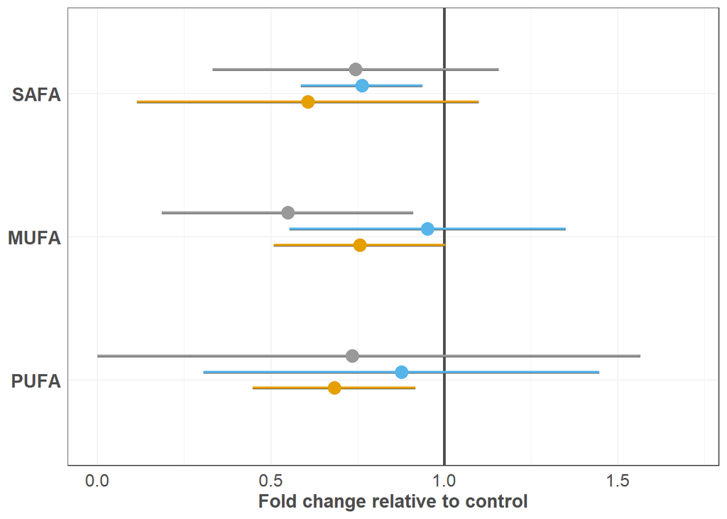

```r
# relative values
biofilm_class_rel <- biofilm_class_abs %>%
  group_by(Class) %>%
  mutate(
    ctrl_mean = mean[treatment == "NC"][1],
    mean = mean / ctrl_mean,
    lwr  = lwr  / ctrl_mean,
    upr  = upr  / ctrl_mean
  ) %>%
  ungroup() %>%
  dplyr::select(-ctrl_mean)


plot_df <- biofilm_class_rel

col_xeno <- c(
  "Pro" = "#E69F00",
  "Cip" = "#56B4E9",
  "Mix" = "#999999"
)

plot_df <- plot_df %>%
  mutate(
    show = ifelse(treatment == "NC", 0, 1),
    treatment = factor(treatment, levels = c("NC","Pro","Cip","Mix")),
    Class = factor(Class, levels = c("PUFA", "MUFA", "SAFA")),
    lwr = ifelse(lwr < 0, 0, lwr)
  )

# plot
fa_biofilm_relative_changes <- ggplot(plot_df, aes(x = mean, y = Class)) +

  geom_vline(xintercept = 1, linewidth = 1, colour = "grey30") +

  geom_errorbarh(
    aes(xmin = lwr, xmax = upr, group = treatment, alpha = show),
    height = 0,
    linewidth = 1,
    colour = "grey30",
    position = position_dodge(width = 0.45),
    show.legend = FALSE
  ) +

  geom_errorbarh(
    aes(xmin = lwr, xmax = upr, colour = treatment, alpha = show),
    height = 0,
    linewidth = 0.8,
    position = position_dodge(width = 0.45),
    show.legend = FALSE
  ) +

  geom_point(
    aes(colour = treatment, alpha = show),
    size = 4,
    position = position_dodge(width = 0.45),
    show.legend = FALSE
  ) +

  scale_colour_manual(
    values = c(
    "NC" = "#009E73",
    "Pro" = "#E69F00",
    "Cip" = "#56B4E9",
    "Mix" = "#999999"
    ),
    labels = c(
      "NC"  = "Control",
      "Cip" = "Ciprofloxacin",
      "Pro" = "Propyzamide",
      "Mix" = "Mixture"
    ),
    name = "Treatment"
  ) +

  scale_alpha_identity() +

  guides(
    colour = guide_legend(override.aes = list(alpha = 1))
  ) +

  labs(
    x = "Fold change relative to control",
    y = NULL
  ) +

  theme_minimal(base_size = 11) +
  theme(
    legend.position = "right",
    legend.title = element_text(size = 12, face = "bold", colour = "grey30"),
    legend.text  = element_text(size = 11, colour = "grey30"),
    panel.background = element_rect(fill = "grey100"),
    axis.title = element_text(size = 13, face = "bold", colour = "grey30"),
    axis.text.x = element_text(size = 12),
    axis.text.y = element_text(size = 13, face = "bold", colour = "grey30"),
    panel.border = element_rect(fill = NA, colour = "grey30"),
    panel.grid.major = element_line(colour = "grey95", size = 0.4),
    panel.grid.minor = element_line(colour = "grey95", size = 0.2)
  )

fa_biofilm_relative_changes
```

```r
# save the plot
ggsave(
  "output/fa_biofilm_relative_changes.png",
  plot = fa_biofilm_relative_changes,
  width = 16.5,
  height = 12,
  units = "cm",
  dpi = 600
)
```

4) Total FA content

```r
# total FA
total_FA_biofilm <- bind_rows(total_SAFA_per_replicate, total_MUFA_per_replicate, total_PUFA_per_replicate)

total_FA_per_replicate <- total_FA_biofilm %>%
  dplyr::group_by(replicate, treatment) %>%
  dplyr::summarize(sum_FA = sum(sum_SAFA, sum_MUFA, sum_PUFA, na.rm = TRUE))
print(total_FA_per_replicate)
```

```
# A tibble: 12 × 3
# Groups:   replicate [12]
   replicate treatment sum_FA
   <chr>     <chr>      <dbl>
 1 B_1       NC          260.
 2 B_10      Cip         258.
 3 B_11      Pro         192.
 4 B_12      Mix         216.
 5 B_2       Cip         227.
 6 B_3       Pro         189.
 7 B_4       Mix         213.
 8 B_5       NC          259.
 9 B_6       Cip         264.
10 B_7       Pro         210.
11 B_8       Mix         166.
12 B_9       NC          352.
```

```r
# statistical differences will be calculated by PERMANOVA

# Calculate mean, se and 95% CI per treatment
mean_FA_ba <- total_FA_per_replicate %>%
  dplyr::group_by(treatment) %>%
  dplyr::summarize(
    mean_FA = mean(sum_FA, na.rm = TRUE),
    n = sum(!is.na(sum_FA)),
    se = sd(sum_FA, na.rm = TRUE) / sqrt(n),
    t_crit = qt(0.975, df = n - 1),
    ci_lower = mean_FA - t_crit * se,
    ci_upper = mean_FA + t_crit * se,
    .groups = "drop"
  ) %>%
  dplyr::select(treatment, mean_FA, ci_lower, ci_upper, se)

# Extract mean of control group for percental difference
control_mean_FA_ba <- mean_FA_ba %>%
  filter(treatment == "NC") %>%
  pull(mean_FA)

# Calculate percental difference from control
mean_FA_ba <- mean_FA_ba %>%
  mutate(percent_diff_from_NC = 100 * (mean_FA - control_mean_FA_ba) / control_mean_FA_ba)

print(mean_FA_ba)
```

```
# A tibble: 4 × 6
  treatment mean_FA ci_lower ci_upper    se percent_diff_from_NC
  <chr>       <dbl>    <dbl>    <dbl> <dbl>                <dbl>
1 Cip          250.     201.     299. 11.3                 -13.9
2 Mix          198.     129.     268. 16.1                 -31.7
3 NC           290.     158.     423. 30.8                   0
4 Pro          197.     169.     226.  6.63                -32.1
```

## 4.2 Histogram FA biofilm

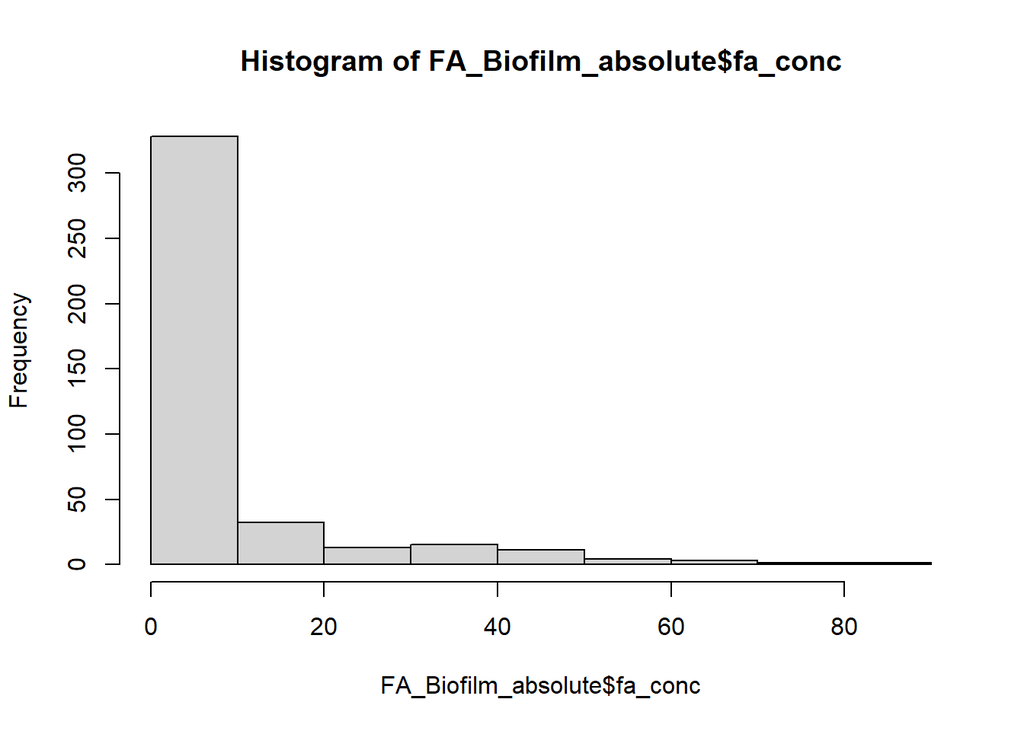

```r
hist(FA_Biofilm_absolute $ fa_conc)
```

```r
skewness(FA_Biofilm_absolute $ fa_conc, na.rm = TRUE)
```

```
[1] 2.723041
```

```r
shapiro.test(FA_Biofilm_absolute $ fa_conc)
```

```
    Shapiro-Wilk normality test

data:  FA_Biofilm_absolute$fa_conc
W = 0.56951, p-value < 2.2e-16
```

Biofilm fatty acid concentration not normal distributed and right skewed.

## 4.3 NMDS FA biofilm

Change table to wide format:

```r
# change table to wide format
FA_Biofilm_absolute_wide_sqrt <-
  pivot_wider(FA_Biofilm_absolute,
              names_from = fa,
              values_from = fa_conc)

# square root transformation, to reduce discriminatory power of dominant fa groups
FA_Biofilm_absolute_wide_sqrt[, 4:37] <- sqrt(FA_Biofilm_absolute_wide_sqrt[, 4:37])

View(FA_Biofilm_absolute_wide_sqrt)

# Only keep columns/FAs with more than 5 non-zero values (fatty acids that have just been found in 5 replicates will be removed)
FA_Biofilm_absolute_wide_sqrt <-
  FA_Biofilm_absolute_wide_sqrt %>%
  dplyr::select(
    1:3,
    where(~sum(. !=0, na.rm = TRUE)>5)
  )
```

Perform metaMDS:

```r
# Rename and ease col-names for later NMDS plot
FA_Biofilm_absolute_wide_sqrt <- FA_Biofilm_absolute_wide_sqrt %>%
  rename(
    `12:0`     = `C12:0`,
    `13:0`     = `C13:0`,
    `14:0`     = `C14:0`,
    `15:0`     = `C15:0`,
    `16:0`     = `C16:0`,
    `16:1`     = `C16:1`,
    `17:1`     = `C17:1`,
    `18:0`     = `C18:0`,
    `18:1`     = `C18:1`,
    `18:2n-6c` = `C18:2(n-6c)`,
    `18:3n-6`  = `C18:3(n-6)`,
    `18:3n-3`  = `C18:3(n-3)`,
    `18:4n-3`  = `C18:4(n-3)`,
    `20:0`     = `C20:0`,
    `20:1`     = `C20:1`,
    `20:2n-6`  = `C20:2(n-6)`,
    `20:4n-6`  = `C20:4(n-6)`,
    `20:5n-3`  = `C20:5(n-3)`,
    `22:0`     = `C22:0`,
    `22:1`     = `C22:1`,
    `22:6n-3`  = `C22:6(n-3)`,
    `24:0`     = `C24:0`
  )

# Remove columns 1:3 for metaMDS
FA_Biofilm_absolute_wide_sqrt <- FA_Biofilm_absolute_wide_sqrt[, -c(1, 2, 3)]

NMDS_Biofilm_absolute <-
  metaMDS(
    FA_Biofilm_absolute_wide_sqrt,
    autotransform = FALSE,
    k = 2 ,
    distance = "bray",
    na.rm = TRUE
  )
```

```
*** Best solution repeated 4 times
```

```r
NMDS_Biofilm_absolute$stress
```

```
[1] 0.09708261
```

Create fa vectors:

```r
# separation in SAFA; MUFA & PUFA to build vectors in NMDS
# "ba" = biofilm absolute
FA_variables.SAFAs_ba <-
  envfit(
    NMDS_Biofilm_absolute,
    subset(
      FA_Biofilm_absolute_wide_sqrt,
      select = c(
        "12:0",
        "13:0",
        "14:0",
        "15:0",
        "16:0",
        "18:0",
        "20:0",
        "22:0",
        "24:0"
      )
    )
    ,
    permutations = 999,
    na.rm = TRUE
  )

FA_variables.MUFAs_ba <-
  envfit(
    NMDS_Biofilm_absolute,
    subset(
      FA_Biofilm_absolute_wide_sqrt,
      select = c(
        "16:1",
        "17:1",
        "18:1",
        "20:1",
        "22:1"
      )
    )
    ,
    permutations = 999,
    na.rm = TRUE
  )

FA_variables.PUFAs_ba <-
  envfit(
    NMDS_Biofilm_absolute,
    subset(
      FA_Biofilm_absolute_wide_sqrt,
      select = c(
        "18:2n-6c",
        "18:3n-6",
        "18:3n-3",
        "18:4n-3",
        "20:2n-6",
        "20:4n-6",
        "20:5n-3",
        "22:6n-3"
      )
    )
    ,
    permutations = 999,
    na.rm = TRUE
  )

# Extract NMDS scores
data.scores_biofilm_absolute = as.data.frame(scores(NMDS_Biofilm_absolute)$sites)

Treatments <-
  FA_Biofilm_absolute$treatment[FA_Biofilm_absolute$fa == "C16:0"]

# add treatment column to NMDS scores
data.scores_biofilm_absolute$Treatment = Treatments

# vectors for SAFA, MUFA and PUFA
SAFAs_coord_cont_ba = as.data.frame(scores(FA_variables.SAFAs_ba, "vectors")) * ordiArrowMul(FA_variables.SAFAs_ba)
MUFAs_coord_cont_ba = as.data.frame(scores(FA_variables.MUFAs_ba, "vectors")) * ordiArrowMul(FA_variables.MUFAs_ba)
PUFAs_coord_cont_ba = as.data.frame(scores(FA_variables.PUFAs_ba, "vectors")) * ordiArrowMul(FA_variables.PUFAs_ba)
```

Plot NMDS:

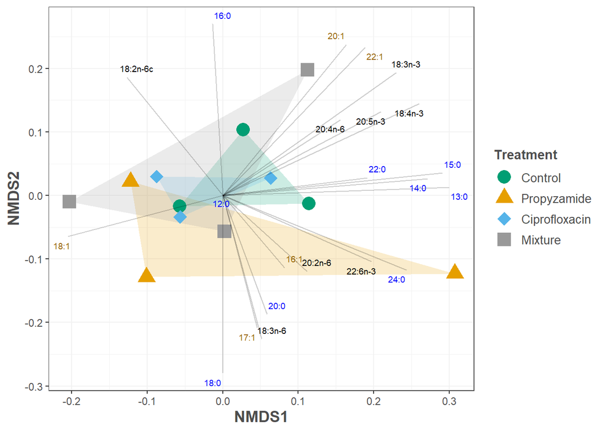

```r
# Reorder treatment variable for the plot
data.scores_biofilm_absolute$Treatment <- factor(
  data.scores_biofilm_absolute$Treatment,
  levels = c("NC", "Pro", "Cip", "Mix"),
  labels  = c("Control", "Propyzamide", "Ciprofloxacin", "Mixture")
)

# Function to rescale coordinates
rescale_vectors <- function(df, scale_factor = 1) {
  df$length <- sqrt(df$NMDS1^2 + df$NMDS2^2)
  max_length <- max(df$length)
  df$NMDS1 <- df$NMDS1 / max_length * scale_factor
  df$NMDS2 <- df$NMDS2 / max_length * scale_factor
  df$length <- NULL
  return(df)
}

# Apply to each group
PUFAs_coord_cont_ba <- rescale_vectors(PUFAs_coord_cont_ba, 0.3)
MUFAs_coord_cont_ba <- rescale_vectors(MUFAs_coord_cont_ba, 0.3)
SAFAs_coord_cont_ba <- rescale_vectors(SAFAs_coord_cont_ba, 0.3)


# Compute convex hull for each Treatment
polygon_data_biofilm_treatment <- data.scores_biofilm_absolute %>%
  group_by(Treatment) %>%
  summarise(hull_points = list(data.frame(
    NMDS1 = NMDS1[chull(NMDS1, NMDS2)],
    NMDS2 = NMDS2[chull(NMDS1, NMDS2)]
  ))) %>%
  unnest(hull_points)

# plot
absol_biofilm_with_vectors = ggplot(data = data.scores_biofilm_absolute, aes(x = NMDS1, y = NMDS2)) +
  geom_polygon(
    data = polygon_data_biofilm_treatment,
    aes(
      x = NMDS1,
      y = NMDS2,
      group = Treatment,
      fill = Treatment
    ),
    alpha = 0.2,
    show.legend = FALSE
  ) +
  geom_point(aes(shape = Treatment, color = Treatment),
             size = 5,
             alpha = 1,
             show.legend = TRUE) +
  scale_shape_manual(values = c(
    "Control" = 16,
    "Propyzamide" = 17,
    "Ciprofloxacin" = 18,
    "Mixture" = 15
  )) +
  scale_color_manual(values = c(
    "Control" = "#009E73",
    "Propyzamide" = "#E69F00",
    "Ciprofloxacin" = "#56B4E9",
    "Mixture" = "#999999"
  )) +
  scale_fill_manual(values = c(
    "Control" = "#009E73",
    "Propyzamide" = "#E69F00",
    "Ciprofloxacin" = "#56B4E9",
    "Mixture" = "#999999"
  ))  +
  labs(color = "Treatment") +
  geom_segment(
    data = PUFAs_coord_cont_ba,
    aes(
      x = 0,
      y = 0,
      xend = NMDS1,
      yend = NMDS2
    ),
    linewidth = 0.5,
    alpha = 0.2,
    colour = "black"
  ) +
  geom_segment(
    data = MUFAs_coord_cont_ba,
    aes(
      x = 0,
      y = 0,
      xend = NMDS1,
      yend = NMDS2
    ),
    linewidth = 0.5,
    alpha = 0.2,
    colour = "black"
  ) +
  geom_segment(
    data = SAFAs_coord_cont_ba,
    aes(
      x = 0,
      y = 0,
      xend = NMDS1,
      yend = NMDS2
    ),
    linewidth = 0.5,
    alpha = 0.2,
    colour = "black"
  ) +
  geom_text_repel(
    data = PUFAs_coord_cont_ba,
    aes(
      x = NMDS1,
      y = NMDS2,
      label = row.names(PUFAs_coord_cont_ba)
    ),
    colour = "black",
    size = 2.5
  ) +
  geom_text_repel(
    data = MUFAs_coord_cont_ba,
    aes(
      x = NMDS1,
      y = NMDS2,
      label = row.names(MUFAs_coord_cont_ba)
    ),
    colour = "#996600",
    size = 2.5
  ) +
  geom_text_repel(
    data = SAFAs_coord_cont_ba,
    aes(
      x = NMDS1,
      y = NMDS2,
      label = row.names(SAFAs_coord_cont_ba)
    ),
    colour = "#0000FF",
    size = 2.5
  ) +
  theme_bw() +
  theme(
    axis.title = element_text(
      size = 13,
      face = "bold",
      colour = "grey30"
    ),
    panel.background = element_blank(),
    panel.border = element_rect(fill = NA, colour = "grey30"),
    legend.key = element_blank(),
    legend.title = element_text(
      size = 11,
      face = "bold",
      colour = "grey30"
    ),
    legend.text = element_text(size = 10, colour = "grey30"),
    plot.margin = margin(
      t = 0.2,
      b = 0.2,
      l = 0.2,
      r = 0.2,
      unit = "cm"
    ),
    panel.grid.major = element_line(colour = "grey95", size = 0.4),
    panel.grid.minor = element_line(colour = "grey95", size = 0.2)
  )

absol_biofilm_with_vectors
```

```r
# position of FA names for publication were manually adjusted in vector graphic with the software Inkscape
```

Save the plot as .png:

```r
ggsave(
  "output/NMDS_Biofilm_absolute.png",
  width = 16.5,
  height = 12,
  units = "cm",
  dpi = 600
)
```

Save the plot as vector graphic:

```r
ggsave(
  "output/NMDS_Biofilm_absolute.svg",
  device = "svg",
  width = 16.5,
  height = 16,
  units = "cm",
  dpi = 600
)
```

## 4.4 PERMANOVA FA biofilm

Create distance matrix with fatty acids:

```r
FA_biofilm_dist <- vegdist(FA_Biofilm_absolute_wide_sqrt, method = 'bray')
```

Separate explanatory variables from fatty acid information:

```r
FA_biofilm_absolute_wide_permanova <-
  pivot_wider(FA_Biofilm_absolute,
              names_from = fa,
              values_from = fa_conc)

# square root transformation again, to reduce discriminatory power of dominant fa groups
FA_biofilm_absolute_wide_permanova[, 4:37] <- sqrt(FA_biofilm_absolute_wide_permanova[, 4:37])

# delete fa columns
FA_biofilm_absolute_wide_permanova <-
  FA_biofilm_absolute_wide_permanova[, c(1, 2, 3)]

FA_biofilm_absolute_wide_permanova$treatment <-
  as.factor(FA_biofilm_absolute_wide_permanova$treatment)
```

Perform PERMANOVA for treatments:

```r
# perform PERMANOVA for treatments
perm_FA_biofilm_treatment <- adonis2(FA_biofilm_dist ~ treatment, data = FA_biofilm_absolute_wide_permanova, permutations = 999)
print(perm_FA_biofilm_treatment)
```

```
Permutation test for adonis under reduced model
Terms added sequentially (first to last)
Permutation: free
Number of permutations: 999

adonis2(formula = FA_biofilm_dist ~ treatment, data = FA_biofilm_absolute_wide_permanova, permutations = 999)
          Df SumOfSqs      R2      F Pr(>F)
treatment  3 0.031983 0.19625 0.6511  0.834
Residual   8 0.130991 0.80375
Total     11 0.162975 1.00000
```

No significant differences between biofilm treatments. Anyway pairwise comparisons (by: Martinez Arbizu, P. (2020). pairwiseAdonis: Pairwise multilevel comparison using adonis. R package version 0.4):

```r
pairwise_results_biofilm_treatment <- pairwise.adonis2(
  FA_biofilm_dist ~ treatment,
  data = FA_biofilm_absolute_wide_permanova,
  permutations = 99
)
```

```
Set of permutations < 'minperm'. Generating entire set.
Set of permutations < 'minperm'. Generating entire set.
Set of permutations < 'minperm'. Generating entire set.
Set of permutations < 'minperm'. Generating entire set.
Set of permutations < 'minperm'. Generating entire set.
Set of permutations < 'minperm'. Generating entire set.
```

```r
# View the results
print(pairwise_results_biofilm_treatment)
```

[output not shown]

```r
# Cip*Pro interaction?
# add presence / absence columns
FA_biofilm_absolute_wide_permanova$Cip <- ifelse(FA_biofilm_absolute_wide_permanova$treatment %in% c("Cip", "Mix"),
                                                 1,
                                                 0)

FA_biofilm_absolute_wide_permanova$Cip <-
  factor(FA_biofilm_absolute_wide_permanova$Cip, levels = c(0, 1))

FA_biofilm_absolute_wide_permanova$Pro <- ifelse(FA_biofilm_absolute_wide_permanova$treatment %in% c("Pro", "Mix"),
                                                 1,
                                                 0)

FA_biofilm_absolute_wide_permanova$Pro <-
  factor(FA_biofilm_absolute_wide_permanova$Pro, levels = c(0, 1))

# sanity check
table(FA_biofilm_absolute_wide_permanova$treatment,
      FA_biofilm_absolute_wide_permanova$Cip)
```

```
      0 1
  Cip 0 3
  Mix 0 3
  NC  3 0
  Pro 3 0
```

```r
table(FA_biofilm_absolute_wide_permanova$treatment,
      FA_biofilm_absolute_wide_permanova$Pro)
```

```
      0 1
  Cip 3 0
  Mix 0 3
  NC  3 0
  Pro 0 3
```

```r
# permanova
perm_FA_biofilm_Cip_Pro <- adonis2(FA_biofilm_dist ~ Cip * Pro,
        data = FA_biofilm_absolute_wide_permanova,
        permutations = 999)

print(perm_FA_biofilm_Cip_Pro)
```

```
Permutation test for adonis under reduced model
Terms added sequentially (first to last)
Permutation: free
Number of permutations: 999

adonis2(formula = FA_biofilm_dist ~ Cip * Pro, data = FA_biofilm_absolute_wide_permanova, permutations = 999)
         Df SumOfSqs      R2      F Pr(>F)
Cip       1 0.008237 0.05054 0.5030  0.843
Pro       1 0.014943 0.09169 0.9126  0.459
Cip:Pro   1 0.008803 0.05402 0.5376  0.834
Residual  8 0.130991 0.80375
Total    11 0.162975 1.00000
```

```r
# no interaction
```

## 4.5 SIMPER FA biofilm

```r
# create extra table with treatments
biofilm_treatments_table <- FA_biofilm_absolute_wide_permanova

View(biofilm_treatments_table)

# Perform SIMPER
simper_FA_biofilm_treatments <-
  with(
    biofilm_treatments_table,
    simper(FA_Biofilm_absolute_wide_sqrt, treatment,  permutations = 999)
  )

summary(simper_FA_biofilm_treatments)
```

```
Contrast: NC_Cip

          average       sd    ratio      ava      avb cumsum     p
18:0     0.019130 0.013874 1.378900 3.383000 3.348000  0.159 0.443
18:1     0.013953 0.007304 1.910400 7.809000 7.297000  0.274 0.869
16:0     0.011179 0.006577 1.699800 7.469000 6.193000  0.367 0.695
18:3n-3  0.009147 0.006652 1.375200 5.184000 4.826000  0.443 0.808
20:5n-3  0.009076 0.006148 1.476200 2.685000 2.380000  0.518 0.517
18:4n-3  0.006834 0.005203 1.313500 3.288000 3.223000  0.575 0.875
16:1     0.006565 0.006553 1.001900 3.662000 4.452000  0.629 0.676
18:2n-6c 0.005904 0.003751 1.573900 7.269000 6.693000  0.678 0.929
20:2n-6  0.005218 0.003093 1.687400 0.918000 0.919000  0.721 0.589
24:0     0.005157 0.004489 1.148800 0.685000 0.837000  0.764 0.763
14:0     0.004453 0.002881 1.545600 3.559000 3.504000  0.801 0.919
18:3n-6  0.004086 0.002013 2.029800 1.885000 1.906000  0.835 0.873
20:4n-6  0.003579 0.002251 1.590000 1.361000 1.210000  0.865 0.337
20:1     0.003269 0.002668 1.225300 1.994000 1.704000  0.892 0.855
12:0     0.002786 0.001901 1.465400 1.106000 0.783000  0.915 0.067 .
22:6n-3  0.002035 0.001283 1.585800 0.799000 0.832000  0.932 0.472
13:0     0.001907 0.001137 1.677300 2.263000 2.200000  0.948 0.326
20:0     0.001738 0.001033 1.682900 1.151000 1.156000  0.962 0.970
22:1     0.001434 0.000932 1.539300 2.029000 1.992000  0.974 0.940
22:0     0.001327 0.000958 1.384800 0.877000 0.927000  0.985 0.801
15:0     0.001131 0.000734 1.541400 0.980000 0.945000  0.994 0.875
17:1     0.000706 0.000571 1.234700 0.737000 0.761000  1.000 0.999
---
Signif. codes:  0 '***' 0.001 '**' 0.01 '*' 0.05 '.' 0.1 ' ' 1

Contrast: NC_Pro

          average       sd    ratio      ava      avb cumsum     p
18:1     0.031345 0.023625 1.326700 7.809000 4.681000  0.172 0.166
16:0     0.024795 0.013407 1.849400 7.469000 4.703000  0.308 0.007 **
18:2n-6c 0.024151 0.024262 0.995400 7.269000 4.576000  0.441 0.098 .
18:0     0.019955 0.013752 1.451100 3.383000 3.709000  0.550 0.349
16:1     0.014781 0.011324 1.305200 3.662000 5.348000  0.631 0.033 *
18:3n-3  0.008792 0.006513 1.349900 5.184000 4.716000  0.680 0.843
20:5n-3  0.008702 0.005278 1.648700 2.685000 2.463000  0.727 0.619
20:1     0.007852 0.007832 1.002500 1.994000 1.214000  0.770 0.276
18:4n-3  0.006912 0.005097 1.356300 3.288000 3.093000  0.808 0.855
```

[output cut: 114 more lines]

```
24:0     0.006403 0.006021 1.063400 0.789000 0.915000  0.837 0.351
20:2n-6  0.005629 0.004490 1.253600 0.679000 0.679000  0.867 0.455
20:0     0.004465 0.003668 1.217000 1.220000 1.164000  0.890 0.112
22:0     0.004205 0.003157 1.331900 0.802000 0.688000  0.912 0.085 .
22:1     0.003963 0.003247 1.220200 1.919000 2.209000  0.934 0.108
17:1     0.003533 0.002777 1.272200 0.708000 0.430000  0.952 0.078 .
20:4n-6  0.002634 0.001666 1.581100 1.159000 0.956000  0.966 0.855
15:0     0.001809 0.001329 1.360400 0.996000 0.938000  0.976 0.167
22:6n-3  0.001700 0.001452 1.170900 0.753000 0.751000  0.985 0.746
12:0     0.001423 0.001376 1.034500 1.062000 0.926000  0.993 0.742
13:0     0.001408 0.001100 1.279600 2.185000 2.214000  1.000 0.852
---
Signif. codes:  0 '***' 0.001 '**' 0.01 '*' 0.05 '.' 0.1 ' ' 1
Permutation: free
Number of permutations: 999
```

```r
simper_sum <- summary(simper_FA_biofilm_treatments)

# save results
out_dir <- "output"
dir.create(out_dir, showWarnings = FALSE)

safe_name <- function(x) gsub("[^A-Za-z0-9_]+", "_", x)

iwalk(simper_sum, function(x, nm) {
  if (is.null(x)) return(invisible(NULL))

  # SIMPER summary as a data.frame:
  # columns: average, sd, ratio, ava, avb, cumsum, p
  # rownames are the fatty acid IDs
  df <- as.data.frame(x)

  # keep rows up to the first that reaches/exceeds 70%
  idx <- which(df$cumsum >= 0.70)[1]
  if (is.na(idx)) idx <- nrow(df)
  out <- df[seq_len(idx), , drop = FALSE]

  # just keep 3 decimals
  out_write <- out
  num_cols <- vapply(out_write, is.numeric, logical(1))
  out_write[, num_cols] <- lapply(out_write[, num_cols, drop = FALSE],
                                  function(col) formatC(col, format = "f", digits = 3))

  file <- file.path(out_dir, paste0(safe_name(nm), "_top70.tsv"))
  # write row names so the TSV mirrors the SIMPER structure
  write.table(out_write, file, sep = "\t", quote = FALSE, col.names = NA)
})
```

```r
# Combine results into a data frame
simper_results_biofilm_treatments <- do.call(rbind, lapply(simper_FA_biofilm_treatments, function(x) {
  # Check if the element contains valid data
  if (!is.null(x$p)) {
    data.frame(
      fatty_acid = names(x$p),
      p = as.numeric(x$p),
      average = as.numeric(x$average),
      sd = as.numeric(x$sd),
      ratio = as.numeric(x$ratio),
      cusum = as.numeric(x$cusum),
      stringsAsFactors = FALSE
    )
  } else {
    NULL  # Skip if no p-values
  }
}))

# Show only significant results
simper_results_biofilm_treatments %>%
  dplyr::filter(p <= 0.05) %>%
  dplyr::select(fatty_acid, p, average, sd, ratio, cusum)
```

```
           fatty_acid     p     average          sd    ratio     cusum
NC_Pro.5         16:0 0.007 0.024795062 0.013406967 1.849416 0.6313639
NC_Pro.6         16:1 0.033 0.014780551 0.011323999 1.305241 0.6796215
NC_Mix.17     20:4n-6 0.041 0.004599664 0.002487812 1.848879 0.9444498
Cip_Mix.11    18:3n-6 0.050 0.010905888 0.007363761 1.481021 0.7883126
Pro_Mix.11    18:3n-6 0.050 0.011401758 0.006013469 1.896037 0.8026106
```

```r
# How often do they occur
simper_results_biofilm_treatments %>%
  dplyr::filter(p <= 0.05) %>%
  dplyr::count(fatty_acid) %>%
  dplyr::arrange(desc(n)) %>%
  print()
```

```
  fatty_acid n
1    18:3n-6 2
2       16:0 1
3       16:1 1
4    20:4n-6 1
```

# 5 Dryweight snails

Unit of soft body dry weight = mg

```r
# insert data (Culture snails from in-house breeding)
dryweight_snails <-
  read.table(file.path("data\\dryweight_snails.txt"),
             header = TRUE, sep = "\t")

View(dryweight_snails)
# 3 snails from the 20 baseline (culture) snails were lost during the analyses.
```

## 5.1 Calculate mean dryweight, se and 95% CI of all treatment snails and the culture snails

```r
mean_dryweight_snails <- dryweight_snails %>%
  group_by(treatment) %>%
  dplyr::summarize(
    mean_dryweight_snails = mean(dryweight_mg, na.rm = TRUE),
    n = sum(!is.na(dryweight_mg)),
    se = sd(dryweight_mg, na.rm = TRUE) / sqrt(n),
    t_crit = qt(0.975, df = n - 1),
    ci_lower = mean_dryweight_snails - t_crit * se,
    ci_upper = mean_dryweight_snails + t_crit * se,
    .groups = "drop"
  ) %>%
  dplyr::select(treatment, mean_dryweight_snails, ci_lower, ci_upper, se)

print(mean_dryweight_snails)
```

```
# A tibble: 5 × 5
  treatment mean_dryweight_snails ci_lower ci_upper     se
  <chr>                     <dbl>    <dbl>    <dbl>  <dbl>
1 Cip                       0.534    0.464    0.604 0.0309
2 Culture                   0.439    0.378    0.499 0.0286
3 Mix                       0.507    0.443    0.572 0.0286
4 NC                        0.679    0.582    0.775 0.0426
5 Pro                       0.553    0.483    0.623 0.0309
```

Snails from feeding assay (fed with biofilm) on average heavier than snails from culture (fed with Tetraphyll flakes).

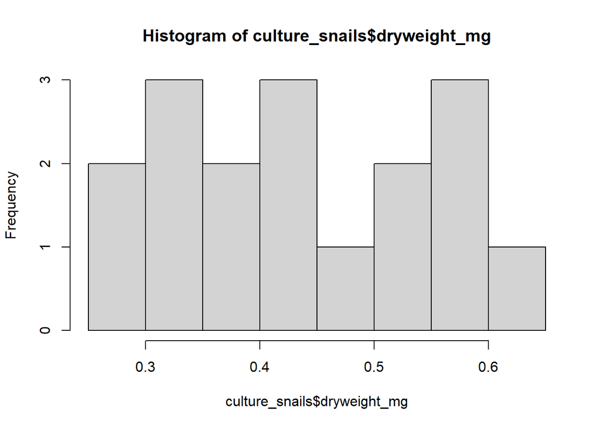

```r
#culture/baseline snails
culture_snails <- dryweight_snails %>%
  dplyr::filter(c(treatment == "Culture"))

hist(culture_snails $ dryweight_mg)
```

```r
skewness(culture_snails $ dryweight_mg, na.rm = TRUE)
```

```
[1] 0.2135628
```

```r
shapiro.test(culture_snails $ dryweight_mg)
```

```
    Shapiro-Wilk normality test

data:  culture_snails$dryweight_mg
W = 0.93454, p-value = 0.259
```

```r
# culture / baseline snails normal distributed

# calculate differences in final dry weight in comparison to culture snails
percentage_differences <- dryweight_snails %>%
  group_by(treatment) %>%
  dplyr::summarize(mean_dryweight = mean(dryweight_mg)) %>%
  mutate(percentage_differences = (mean_dryweight / mean_dryweight[treatment == "Culture"]) * 100 - 100)

percentage_differences
```

```
# A tibble: 5 × 3
  treatment mean_dryweight percentage_differences
  <chr>              <dbl>                  <dbl>
1 Cip                0.534                   21.8
2 Culture            0.439                    0
3 Mix                0.507                   15.7
4 NC                 0.679                   54.8
5 Pro                0.553                   26.1
```

## 5.2 Histogram

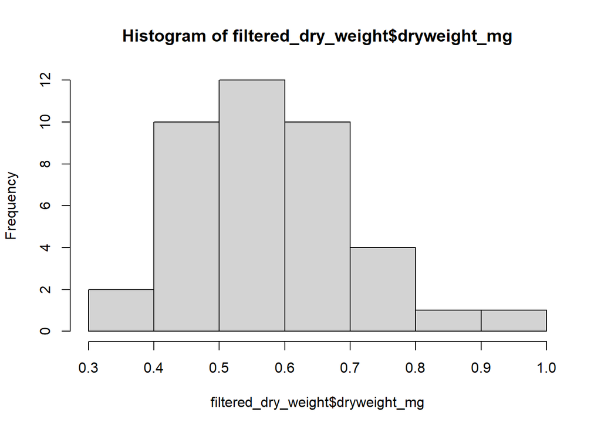

```r
# filter culture snails
filtered_dry_weight <- dryweight_snails %>%
  filter(!treatment %in% c("Culture"))

hist(filtered_dry_weight $ dryweight_mg)
```

```r
skewness(filtered_dry_weight $ dryweight_mg, na.rm = TRUE)
```

```
[1] 0.5211954
```

```r
shapiro.test(filtered_dry_weight $ dryweight_mg)
```

```
    Shapiro-Wilk normality test

data:  filtered_dry_weight$dryweight_mg
W = 0.9753, p-value = 0.52
```

Soft tissue dry weights normal distributed.

## 5.3 Model dry weight snails

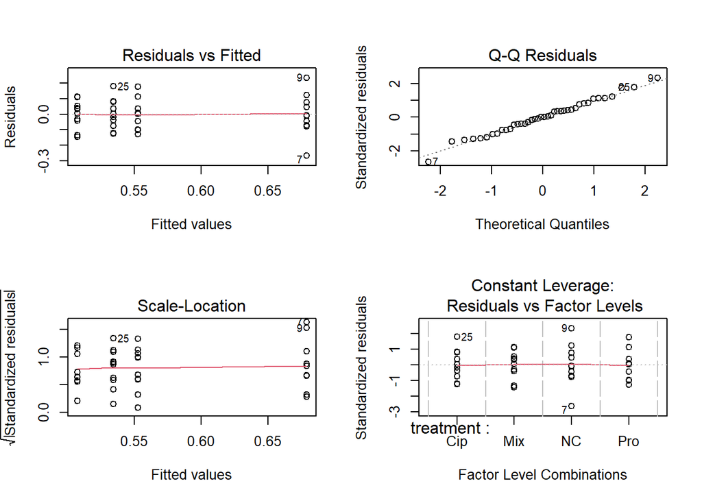

```r
# explanatory variable treatment as factor
filtered_dry_weight $ treatment <- factor(filtered_dry_weight $ treatment)

model_snails <- lm(dryweight_mg ~ treatment, data = filtered_dry_weight)
par(mfrow = c(2, 2))
plot(model_snails) # normal distribution assumed
```

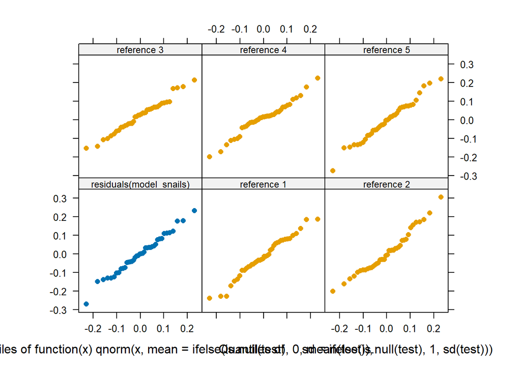

```r
qreference(residuals(model_snails))
```

```r
drop1(model_snails, test = 'F')
```

```
Single term deletions

Model:
dryweight_mg ~ treatment
          Df Sum of Sq     RSS     AIC F value   Pr(>F)
<none>                 0.40937 -175.28
treatment  3   0.17317 0.58255 -167.17  5.0763 0.004928 **
---
Signif. codes:  0 '***' 0.001 '**' 0.01 '*' 0.05 '.' 0.1 ' ' 1
```

Explanatory variable “treatment” highly significant.

```r
dw_snails_inter <- lsmeans(model_snails, ~ treatment)

dw_snails_inter_dunn1 <- contrast(dw_snails_inter, 'pairwise')

dw_snails_inter_dunn_sum1 <- summary(dw_snails_inter_dunn1, infer = TRUE, adjust = 'mvt')

dw_snails_inter_dunn1
```

```
 contrast  estimate     SE df t.ratio p.value
 Cip - Mix   0.0269 0.0477 36   0.564  0.9422
 Cip - NC   -0.1445 0.0477 36  -3.031  0.0223
 Cip - Pro  -0.0186 0.0477 36  -0.391  0.9794
 Mix - NC   -0.1714 0.0477 36  -3.595  0.0051
 Mix - Pro  -0.0455 0.0477 36  -0.955  0.7757
 NC - Pro    0.1259 0.0477 36   2.640  0.0564

P value adjustment: tukey method for comparing a family of 4 estimates
```

Significant difference between dry weight of Cip and Mix snails compared to NC; almost significant difference between Pro treatment and NC.

Test for interaction effects of Cip and Pro:

```r
# interaction effect model with presence / absence of single xenobiotics
filtered_dry_weight$Cip <- ifelse(filtered_dry_weight$treatment %in% c("Cip", "Mix"),
                                1, 0)

filtered_dry_weight$Cip <- factor(filtered_dry_weight$Cip, levels = c(0, 1))

filtered_dry_weight$Pro <- ifelse(filtered_dry_weight$treatment %in% c("Pro", "Mix"),
                                1, 0)

filtered_dry_weight$Pro <- factor(filtered_dry_weight$Pro, levels = c(0, 1))

# sanity check
table(filtered_dry_weight$treatment,
      filtered_dry_weight$Cip,
      filtered_dry_weight$Pro)
```

```
, ,  = 0


       0  1
  Cip  0 10
  Mix  0  0
  NC  10  0
  Pro  0  0

, ,  = 1


       0  1
  Cip  0  0
  Mix  0 10
  NC   0  0
  Pro 10  0
```

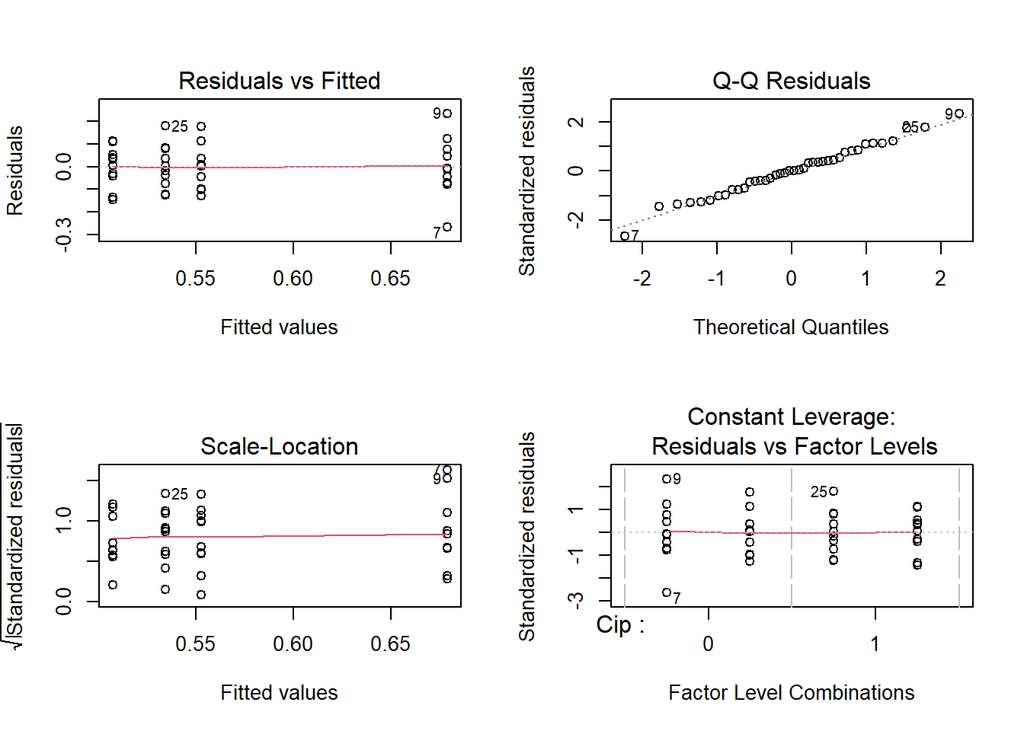

```r
# interaction model
model_dryweight_interact <- lm(dryweight_mg ~ Cip * Pro, data = filtered_dry_weight)
par(mfrow = c(2, 2))
plot(model_dryweight_interact) # point cloud looks evenly distributed --> normal distribution
```

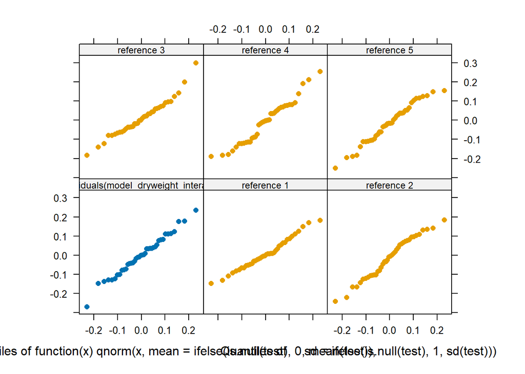

```r
qreference(residuals(model_dryweight_interact))
```

```r
drop1(model_dryweight_interact, test = 'F')
```

```
Single term deletions

Model:
dryweight_mg ~ Cip * Pro
        Df Sum of Sq     RSS     AIC F value Pr(>F)
<none>               0.40937 -175.28
Cip:Pro  1  0.024512 0.43388 -174.95  2.1556 0.1507
```

```r
# Cip:Pro interaction not significant
```

```r
# df.ref only control values
df.ref.dryweight<- filtered_dry_weight |>
  dplyr::filter(Cip == 0, Pro == 0)

nd_dryweight_snails <- nd.generator(df.ref.dryweight, stressor1 = "Cip", stressor2 = "Pro", diff = NULL)

#sanity check
table(nd_dryweight_snails$dataset, nd_dryweight_snails$Cip)
```

```
       0  1
  C   10  0
  S1   0 10
  S12  0 10
  S2  10  0
```

```r
table(nd_dryweight_snails$dataset, nd_dryweight_snails$Pro)
```

```
       0  1
  C   10  0
  S1  10  0
  S12  0 10
  S2   0 10
```

```r
#check for AD, MU (all values >0) and OD
hyp_all_dryweight_snails <- predictions(
  model_dryweight_interact,
  newdata = nd_dryweight_snails,
  hypothesis = function(x) {
    hypothesis.function(
      x,
      stressor1 = "Cip",
      stressor2 = "Pro",
      null = "all",        # <- AD, MU, DO together
      strategy = "average"
    )
  }
) |>
  inferences(method = "simulation")

hyp_all_dryweight_snails
```

```
 Term Estimate   2.5 % 97.5 %
   ad   0.0990 -0.0309 0.2324
   do  -0.0269 -0.0964 0.0753
   mu   0.1535 -0.0869 0.3988

Type: response
```

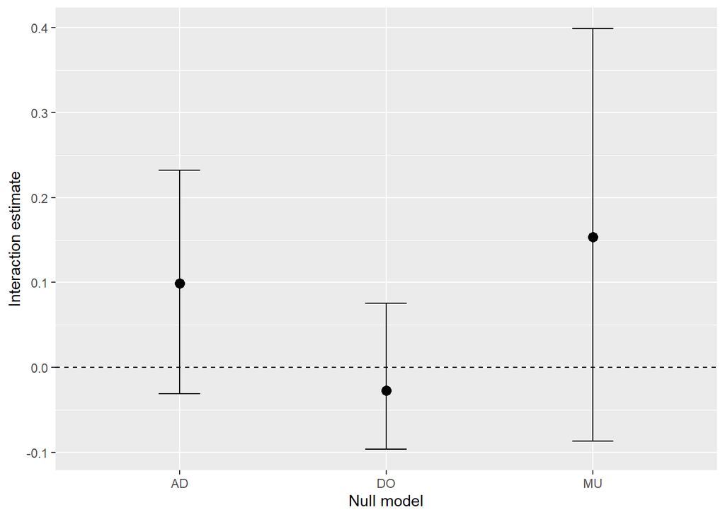

```r
hyp_all_dryweight_snails$term <- dplyr::recode(hyp_all_dryweight_snails$term,
                                    "ad" = "AD",
                                    "do" = "DO",
                                    "mu" = "MU")

ggplot(hyp_all_dryweight_snails, aes(x = term, y = estimate)) +
  geom_point(size = 3) +
  geom_errorbar(aes(ymin = conf.low, ymax = conf.high), width = 0.2) +
  geom_hline(yintercept = 0, linetype = "dashed") +
  labs(x = "Null model", y = "Interaction estimate")
```